# Loan Application Risk Analysis (by Khairulrazi)

```python
#import necessary libraries
import pandas as pd
import seaborn as sns
import matplotlib.pyplot as plt
import numpy as np

import seaborn as sns
import matplotlib.pyplot as plt

#load machine learning
from sklearn.naive_bayes import GaussianNB

from sklearn.feature_selection import RFECV
from sklearn.metrics import mean_squared_error, r2_score



#load KMeans
from sklearn.cluster import KMeans

from sklearn.preprocessing import MinMaxScaler

#warnings
import warnings
warnings.filterwarnings('ignore')
```

### Load data

```python
#load loan.csv
loan_df = pd.read_csv('data/loan.csv')

#load payment.csv
payment_df = pd.read_csv('data/payment.csv')

#load clarity_underwriting_variables.csv
clarity_df = pd.read_csv('data/clarity_underwriting_variables.csv')
```

## Exploratory Data Analysis (EDA)

### Data Cleaning and Merging

check for missing values and remove rows and handle missing values

`Unique Identifiers:`

- loanId
- underwritingid

```python
print("---------------------------------------------------------")
loan_missing_values = loan_df.isnull().sum()
print("missing values in loan.csv: ")
print(loan_missing_values)
print("---------------------------------------------------------")
payment_missing_values = payment_df.isnull().sum()
print("missing values in payment.csv: ")
print(payment_missing_values)
```

```
---------------------------------------------------------
missing values in loan.csv:
loanId                                 256
anon_ssn                                 0
payFrequency                          1273
apr                                   3922
applicationDate                          0
originated                               0
originatedDate                      531638
nPaidOff                                24
approved                                 0
isFunded                                 0
loanStatus                             391
loanAmount                            2250
originallyScheduledPaymentAmount         0
state                                  132
leadType                                 0
leadCost                                 0
fpStatus                            525959
clarityFraudId                      219989
hasCF                                    0
dtype: int64
---------------------------------------------------------
missing values in payment.csv:
loanId                    0
installmentIndex          0
isCollection              0
paymentDate               0
principal                 0
fees                      0
paymentAmount             0
paymentStatus             0
paymentReturnCode    657831
dtype: int64
```

```python
#remove rows with missing values
loan_df = loan_df.dropna(subset=['loanId', 'loanStatus','payFrequency','nPaidOff', 'state'])
#reset index
loan_df = loan_df.reset_index(drop=True)
```

```python
#replace missing values with mean for loanAmount and apr
loan_df["loanAmount"].fillna(loan_df['loanAmount'].mean(), inplace=True)
loan_df["apr"].fillna(loan_df['apr'].mean(), inplace=True)
```

```python
print("---------------------------------------------------------")
loan_missing_values = loan_df.isnull().sum()
print("missing values in loan.csv: ")
print(loan_missing_values)
print("---------------------------------------------------------")
payment_missing_values = payment_df.isnull().sum()
print("missing values in payment.csv: ")
print(payment_missing_values)
print("---------------------------------------------------------")
clarity_missing_values = clarity_df.isnull().sum()
print("missing values in clarity_underwriting_variables.csv: ")
print(payment_missing_values)
```

```
---------------------------------------------------------
missing values in loan.csv:
loanId                                   0
anon_ssn                                 0
payFrequency                             0
apr                                      0
applicationDate                          0
originated                               0
originatedDate                      529872
nPaidOff                                 0
approved                                 0
isFunded                                 0
loanStatus                               0
loanAmount                               0
originallyScheduledPaymentAmount         0
state                                    0
leadType                                 0
leadCost                                 0
fpStatus                            525744
clarityFraudId                      219686
hasCF                                    0
dtype: int64
---------------------------------------------------------
missing values in payment.csv:
loanId                    0
installmentIndex          0
isCollection              0
paymentDate               0
principal                 0
fees                      0
paymentAmount             0
paymentStatus             0
paymentReturnCode    657831
dtype: int64
---------------------------------------------------------
missing values in clarity_underwriting_variables.csv:
loanId                    0
installmentIndex          0
isCollection              0
paymentDate               0
principal                 0
fees                      0
paymentAmount             0
paymentStatus             0
paymentReturnCode    657831
dtype: int64
```

```python
# Identify duplicates
loan_duplicates = loan_df.duplicated()

# Filter and print the duplicate rows
loan_df_duplicates = loan_df[loan_duplicates]
print(loan_df_duplicates)
```

```
Empty DataFrame
Columns: [loanId, anon_ssn, payFrequency, apr, applicationDate, originated, originatedDate, nPaidOff, approved, isFunded, loanStatus, loanAmount, originallyScheduledPaymentAmount, state, leadType, leadCost, fpStatus, clarityFraudId, hasCF]
Index: []
```

```python
#change data in payFrequency column
frequency_mapping = {
    'B': 'biweekly',
    'I': 'irregular',
    'M': 'monthly',
    'S': 'semi monthly',
    'W': 'weekly'
}

# Replace values in payFrequency column
loan_df['payFrequency'] = loan_df['payFrequency'].map(frequency_mapping)
loan_df
```

|  | loanId | anon_ssn | payFrequency | apr | applicationDate | originated | originatedDate | nPaidOff | approved | isFunded | loanStatus | loanAmount | originallyScheduledPaymentAmount | state | leadType | leadCost | fpStatus | clarityFraudId | hasCF |
| --- | --- | --- | --- | --- | --- | --- | --- | --- | --- | --- | --- | --- | --- | --- | --- | --- | --- | --- | --- |
| 0 | LL-I-07399092 | beff4989be82aab4a5b47679216942fd | biweekly | 360.0 | 2016-02-23T17:29:01.940000 | False | NaN | 0.0 | False | 0 | Withdrawn Application | 500.0 | 978.27 | IL | bvMandatory | 6 | NaN | 5669ef78e4b0c9d3936440e6 | 1 |
| 1 | LL-I-06644937 | 464f5d9ae4fa09ece4048d949191865c | biweekly | 199.0 | 2016-01-19T22:07:36.778000 | True | 2016-01-20T15:49:18.846000 | 0.0 | True | 1 | Paid Off Loan | 3000.0 | 6395.19 | CA | prescreen | 0 | Checked | 569eb3a3e4b096699f685d64 | 1 |
| 2 | LL-I-10707532 | 3c174ae9e2505a5f9ddbff9843281845 | biweekly | 590.0 | 2016-08-01T13:51:14.709000 | False | NaN | 0.0 | False | 0 | Withdrawn Application | 400.0 | 1199.45 | MO | bvMandatory | 3 | NaN | 579eab11e4b0d0502870ef2f | 1 |
| 3 | LL-I-02272596 | 9be6f443bb97db7e95fa0c281d34da91 | biweekly | 360.0 | 2015-08-06T23:58:08.880000 | False | NaN | 0.0 | False | 0 | Withdrawn Application | 500.0 | 1074.05 | IL | bvMandatory | 3 | NaN | 555b1e95e4b0f6f11b267c18 | 1 |
| 4 | LL-I-09542882 | 63b5494f60b5c19c827c7b068443752c | biweekly | 590.0 | 2016-06-05T22:31:34.304000 | False | NaN | 0.0 | False | 0 | Rejected | 350.0 | 814.37 | NV | bvMandatory | 3 | NaN | 5754a91be4b0c6a2bf424772 | 1 |
| ... | ... | ... | ... | ... | ... | ... | ... | ... | ... | ... | ... | ... | ... | ... | ... | ... | ... | ... | ... |
| 575890 | LL-I-12122269 | 801262d04720d32040612759857f4147 | biweekly | 590.0 | 2016-11-08T17:32:33.554000 | False | NaN | 0.0 | False | 0 | Withdrawn Application | 400.0 | 1292.41 | NV | bvMandatory | 3 | NaN | 58220cdde4b051c58d919c1f | 1 |
| 575891 | LL-I-16183462 | e37750de9d99a67e0fa96a51e86fdf5b | semi monthly | 490.0 | 2017-01-24T22:20:59.818000 | False | NaN | 0.0 | False | 0 | Withdrawn Application | 1000.0 | 2592.39 | MO | lead | 25 | NaN | 5887d349e4b08f249ac45e2f | 1 |
| 575892 | LL-I-06962710 | d7e55e85266208ac4c353f42ebcde5ca | biweekly | 590.0 | 2016-02-02T03:05:47.797000 | False | NaN | 0.0 | False | 0 | Withdrawn Application | 300.0 | 844.75 | IN | bvMandatory | 6 | NaN | 550b1f59e4b0d4592e28c84e | 1 |
| 575893 | LL-I-01253468 | c3b35307cb36116bf59574f9138d3dad | biweekly | 550.0 | 2015-05-21T20:19:49.639000 | False | NaN | 0.0 | False | 0 | Withdrawn Application | 300.0 | 770.80 | OH | organic | 6 | NaN | NaN | 0 |
| 575894 | LL-I-04733921 | dc0a43b16c037ee5d0142daebb5db83a | irregular | 590.0 | 2015-11-17T22:04:20.862000 | False | NaN | 0.0 | False | 0 | Rejected | 400.0 | 1214.63 | OH | bvMandatory | 6 | NaN | 564f801ae4b05a02bef951e8 | 1 |

575895 rows × 19 columns

```python
loan_payment_df = loan_df.merge(payment_df, on='loanId', how='inner')
loan_payment_df
```

|  | loanId | anon_ssn | payFrequency | apr | applicationDate | originated | originatedDate | nPaidOff | approved | isFunded | ... | clarityFraudId | hasCF | installmentIndex | isCollection | paymentDate | principal | fees | paymentAmount | paymentStatus | paymentReturnCode |
| --- | --- | --- | --- | --- | --- | --- | --- | --- | --- | --- | --- | --- | --- | --- | --- | --- | --- | --- | --- | --- | --- |
| 0 | LL-I-06644937 | 464f5d9ae4fa09ece4048d949191865c | biweekly | 199.0 | 2016-01-19T22:07:36.778000 | True | 2016-01-20T15:49:18.846000 | 0.0 | True | 1 | ... | 569eb3a3e4b096699f685d64 | 1 | 1 | False | 2016-01-27T05:00:00 | 151.98 | 114.49 | 266.47 | Checked | NaN |
| 1 | LL-I-06644937 | 464f5d9ae4fa09ece4048d949191865c | biweekly | 199.0 | 2016-01-19T22:07:36.778000 | True | 2016-01-20T15:49:18.846000 | 0.0 | True | 1 | ... | 569eb3a3e4b096699f685d64 | 1 | 2 | False | 2016-02-10T05:00:00 | 49.08 | 217.39 | 266.47 | Checked | NaN |
| 2 | LL-I-06644937 | 464f5d9ae4fa09ece4048d949191865c | biweekly | 199.0 | 2016-01-19T22:07:36.778000 | True | 2016-01-20T15:49:18.846000 | 0.0 | True | 1 | ... | 569eb3a3e4b096699f685d64 | 1 | 3 | False | 2016-02-24T05:00:00 | 52.83 | 213.64 | 266.47 | Checked | NaN |
| 3 | LL-I-06644937 | 464f5d9ae4fa09ece4048d949191865c | biweekly | 199.0 | 2016-01-19T22:07:36.778000 | True | 2016-01-20T15:49:18.846000 | 0.0 | True | 1 | ... | 569eb3a3e4b096699f685d64 | 1 | 4 | False | 2016-03-09T05:00:00 | 56.86 | 209.61 | 266.47 | Checked | NaN |
| 4 | LL-I-06644937 | 464f5d9ae4fa09ece4048d949191865c | biweekly | 199.0 | 2016-01-19T22:07:36.778000 | True | 2016-01-20T15:49:18.846000 | 0.0 | True | 1 | ... | 569eb3a3e4b096699f685d64 | 1 | 5 | False | 2016-03-23T04:00:00 | 61.20 | 205.27 | 266.47 | Checked | NaN |
| ... | ... | ... | ... | ... | ... | ... | ... | ... | ... | ... | ... | ... | ... | ... | ... | ... | ... | ... | ... | ... | ... |
| 688976 | LL-I-13311312 | 043dd86c24c63c8968082fa3ad7a8911 | weekly | 645.0 | 2016-12-16T20:20:30.157000 | True | 2016-12-16T23:15:06.874000 | 0.0 | True | 1 | ... | 5840ad86e4b0bb9d6980127f | 1 | 23 | False | 2017-05-25T04:00:00 | 21.85 | 17.38 | 39.23 | Cancelled | NaN |
| 688977 | LL-I-13311312 | 043dd86c24c63c8968082fa3ad7a8911 | weekly | 645.0 | 2016-12-16T20:20:30.157000 | True | 2016-12-16T23:15:06.874000 | 0.0 | True | 1 | ... | 5840ad86e4b0bb9d6980127f | 1 | 24 | False | 2017-06-01T04:00:00 | 24.56 | 14.67 | 39.23 | Cancelled | NaN |
| 688978 | LL-I-13311312 | 043dd86c24c63c8968082fa3ad7a8911 | weekly | 645.0 | 2016-12-16T20:20:30.157000 | True | 2016-12-16T23:15:06.874000 | 0.0 | True | 1 | ... | 5840ad86e4b0bb9d6980127f | 1 | 25 | False | 2017-06-08T04:00:00 | 27.59 | 11.64 | 39.23 | Cancelled | NaN |
| 688979 | LL-I-13311312 | 043dd86c24c63c8968082fa3ad7a8911 | weekly | 645.0 | 2016-12-16T20:20:30.157000 | True | 2016-12-16T23:15:06.874000 | 0.0 | True | 1 | ... | 5840ad86e4b0bb9d6980127f | 1 | 26 | False | 2017-06-15T04:00:00 | 31.01 | 8.22 | 39.23 | Cancelled | NaN |
| 688980 | LL-I-13311312 | 043dd86c24c63c8968082fa3ad7a8911 | weekly | 645.0 | 2016-12-16T20:20:30.157000 | True | 2016-12-16T23:15:06.874000 | 0.0 | True | 1 | ... | 5840ad86e4b0bb9d6980127f | 1 | 27 | False | 2017-06-22T04:00:00 | 35.46 | 4.39 | 39.85 | Cancelled | NaN |

688981 rows × 27 columns

### Are loans paid on time?

- validate if payment are made on time

```python
# Convert paymentDate to datetime format
loan_payment_df['paymentDate'] = pd.to_datetime(loan_payment_df['paymentDate'])

# # Filter loan_payment_df for paymentStatus = 'CHECKED'
loan_payment_df = loan_payment_df[loan_payment_df['paymentStatus'] == 'Checked']

# Sort the merged dataframe by loanId and paymentDate
loan_payment_df.sort_values(['loanId', 'paymentDate'], inplace=True)


# Calculate time difference between consecutive payment dates for each loan
loan_payment_df['paymentInterval'] = loan_payment_df.groupby('loanId')['paymentDate'].diff()

# Map pay frequency to calculate time difference
frequency_mapping = {
    'biweekly': pd.Timedelta(weeks=2),
    'irregular': None,  # Add mapping for irregular payments if applicable
    'monthly': pd.Timedelta(days=31),  # Assuming 31 days for simplicity
    'semi monthly': pd.Timedelta(days=15),
    'weekly': pd.Timedelta(weeks=1)
}

tolerance_days = 1  # Tolerance of +- 2 days
loan_payment_df['expectedInterval'] = loan_payment_df['payFrequency'].map(frequency_mapping)

# Create pay_on_time column
loan_payment_df['pay_on_time'] = (loan_payment_df['paymentInterval'] <= loan_payment_df['expectedInterval']).map({True: 'TRUE', False: 'FALSE'})

loan_payment_df
```

|  | loanId | anon_ssn | payFrequency | apr | applicationDate | originated | originatedDate | nPaidOff | approved | isFunded | ... | isCollection | paymentDate | principal | fees | paymentAmount | paymentStatus | paymentReturnCode | paymentInterval | expectedInterval | pay_on_time |
| --- | --- | --- | --- | --- | --- | --- | --- | --- | --- | --- | --- | --- | --- | --- | --- | --- | --- | --- | --- | --- | --- |
| 169685 | LL-I-00003578 | 5f079f3b9f0e103b6f5cc9f0c8b25dcd | biweekly | 478.67 | 2014-12-04T21:30:27.564000 | True | 2014-12-05T15:28:07.491000 | 1.0 | True | 1 | ... | False | 2014-12-16 05:00:00 | 0.00 | 115.72 | 115.72 | Checked | NaN | NaT | 14 days | FALSE |
| 169686 | LL-I-00003578 | 5f079f3b9f0e103b6f5cc9f0c8b25dcd | biweekly | 478.67 | 2014-12-04T21:30:27.564000 | True | 2014-12-05T15:28:07.491000 | 1.0 | True | 1 | ... | False | 2014-12-30 05:00:00 | 27.20 | 147.28 | 174.48 | Checked | NaN | 14 days | 14 days | TRUE |
| 169687 | LL-I-00003578 | 5f079f3b9f0e103b6f5cc9f0c8b25dcd | biweekly | 478.67 | 2014-12-04T21:30:27.564000 | True | 2014-12-05T15:28:07.491000 | 1.0 | True | 1 | ... | False | 2015-01-07 05:00:00 | 412.82 | 88.18 | 500.00 | Checked | NaN | 8 days | 14 days | TRUE |
| 169688 | LL-I-00003578 | 5f079f3b9f0e103b6f5cc9f0c8b25dcd | biweekly | 478.67 | 2014-12-04T21:30:27.564000 | True | 2014-12-05T15:28:07.491000 | 1.0 | True | 1 | ... | False | 2015-01-13 05:00:00 | 359.98 | 91.02 | 345.00 | Checked | NaN | 6 days | 14 days | TRUE |
| 615020 | LL-I-00003606 | 8aada56c412068810639ed9313d6d7fd | semi monthly | 478.67 | 2014-12-04T21:43:08.481000 | True | 2014-12-05T15:35:01.795000 | 0.0 | True | 1 | ... | False | 2014-12-15 05:00:00 | 0.00 | 47.33 | 47.33 | Checked | NaN | NaT | 15 days | FALSE |
| ... | ... | ... | ... | ... | ... | ... | ... | ... | ... | ... | ... | ... | ... | ... | ... | ... | ... | ... | ... | ... | ... |
| 166936 | LP-I-00000145 | b7072e7be712311d8b90e2cc2847ee87 | biweekly | 29.99 | 2016-02-29T00:53:13.314000 | True | 2016-03-02T14:45:11.156000 | 0.0 | True | 1 | ... | False | 2016-06-24 04:00:00 | 63.55 | 3.74 | 67.29 | Checked | NaN | 14 days | 14 days | TRUE |
| 166937 | LP-I-00000145 | b7072e7be712311d8b90e2cc2847ee87 | biweekly | 29.99 | 2016-02-29T00:53:13.314000 | True | 2016-03-02T14:45:11.156000 | 0.0 | True | 1 | ... | False | 2016-07-08 04:00:00 | 64.28 | 3.01 | 67.29 | Checked | NaN | 14 days | 14 days | TRUE |
| 166938 | LP-I-00000145 | b7072e7be712311d8b90e2cc2847ee87 | biweekly | 29.99 | 2016-02-29T00:53:13.314000 | True | 2016-03-02T14:45:11.156000 | 0.0 | True | 1 | ... | False | 2016-07-22 04:00:00 | 65.02 | 2.27 | 67.29 | Checked | NaN | 14 days | 14 days | TRUE |
| 166939 | LP-I-00000145 | b7072e7be712311d8b90e2cc2847ee87 | biweekly | 29.99 | 2016-02-29T00:53:13.314000 | True | 2016-03-02T14:45:11.156000 | 0.0 | True | 1 | ... | False | 2016-08-05 04:00:00 | 65.77 | 1.52 | 67.29 | Checked | NaN | 14 days | 14 days | TRUE |
| 166940 | LP-I-00000145 | b7072e7be712311d8b90e2cc2847ee87 | biweekly | 29.99 | 2016-02-29T00:53:13.314000 | True | 2016-03-02T14:45:11.156000 | 0.0 | True | 1 | ... | False | 2016-08-19 04:00:00 | 66.53 | 0.77 | 67.30 | Checked | NaN | 14 days | 14 days | TRUE |

209513 rows × 30 columns

```python
# Replace 'pay_on_time' with NaN where paymentStatus is not 'Checked' or 'Skipped'
loan_payment_df.loc[~loan_payment_df['paymentStatus'].isin(['Checked', 'Skipped']), 'pay_on_time'] = np.nan
```

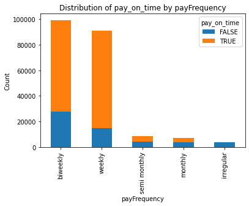

```python
# Calculate the counts of pay_on_time and late payments for each payFrequency
payment_counts = loan_payment_df.groupby(['payFrequency', 'pay_on_time']).size().unstack()

# Convert payFrequency to categorical data with specified order
pay_freq_order = ['biweekly', 'weekly', 'semi monthly', 'monthly', 'irregular']
payment_counts = payment_counts.reindex(pay_freq_order)

# Calculate the sum of each payFrequency category
payment_counts_sum = payment_counts.sum(axis=1)

# Sort the DataFrame based on the sums in descending order
payment_counts_sorted = payment_counts.loc[payment_counts_sum.sort_values(ascending=False).index]

# Plot the sorted stacked bar chart
payment_counts_sorted.plot(kind='bar', stacked=True)

# Add labels and title
plt.xlabel('payFrequency')
plt.ylabel('Count')
plt.title('Distribution of pay_on_time by payFrequency')

# Show the plot
plt.show()
```

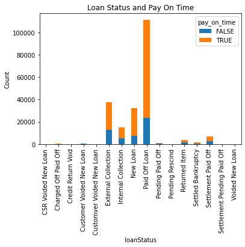

```python
# Calculate the counts of loanStatus and pay_on_time
status_counts = loan_payment_df.groupby(['loanStatus', 'pay_on_time']).size().unstack()


# Set the figure size
plt.figure(figsize=(10, 10))

# Plot the stacked bar chart
status_counts.plot(kind='bar', stacked=True)

# Add labels and title
plt.xlabel('loanStatus')
plt.ylabel('Count')
plt.title('Loan Status and Pay On Time')

# Show the plot
plt.show()
```

insights found from stacked bar chart:

- most consumer paid off their loans on time

### find loans that are fully paid

- calculate total principal paid and loanAmount

```python
# Filter the loan_payment_df for paymentStatus = 'Checked'
checked_payments = loan_payment_df[loan_payment_df['paymentStatus'] == 'Checked']

# Calculate the total principal for each loanId
total_principal = checked_payments.groupby('loanId')['principal'].sum()

# Merge the total_principal with loan_df
loan_df = loan_df.merge(total_principal, on='loanId', how='left')
loan_df.rename(columns={'principal': 'total_principal_paid'}, inplace=True)

# Create the isPaidOff column
loan_df['isPaidOff'] = np.where(loan_df['total_principal_paid'] >= loan_df['loanAmount'], 'TRUE', 'FALSE')

loan_df
```

|  | loanId | anon_ssn | payFrequency | apr | applicationDate | originated | originatedDate | nPaidOff | approved | isFunded | ... | loanAmount | originallyScheduledPaymentAmount | state | leadType | leadCost | fpStatus | clarityFraudId | hasCF | total_principal_paid | isPaidOff |
| --- | --- | --- | --- | --- | --- | --- | --- | --- | --- | --- | --- | --- | --- | --- | --- | --- | --- | --- | --- | --- | --- |
| 0 | LL-I-07399092 | beff4989be82aab4a5b47679216942fd | biweekly | 360.0 | 2016-02-23T17:29:01.940000 | False | NaN | 0.0 | False | 0 | ... | 500.0 | 978.27 | IL | bvMandatory | 6 | NaN | 5669ef78e4b0c9d3936440e6 | 1 | NaN | FALSE |
| 1 | LL-I-06644937 | 464f5d9ae4fa09ece4048d949191865c | biweekly | 199.0 | 2016-01-19T22:07:36.778000 | True | 2016-01-20T15:49:18.846000 | 0.0 | True | 1 | ... | 3000.0 | 6395.19 | CA | prescreen | 0 | Checked | 569eb3a3e4b096699f685d64 | 1 | 3000.0 | TRUE |
| 2 | LL-I-10707532 | 3c174ae9e2505a5f9ddbff9843281845 | biweekly | 590.0 | 2016-08-01T13:51:14.709000 | False | NaN | 0.0 | False | 0 | ... | 400.0 | 1199.45 | MO | bvMandatory | 3 | NaN | 579eab11e4b0d0502870ef2f | 1 | NaN | FALSE |
| 3 | LL-I-02272596 | 9be6f443bb97db7e95fa0c281d34da91 | biweekly | 360.0 | 2015-08-06T23:58:08.880000 | False | NaN | 0.0 | False | 0 | ... | 500.0 | 1074.05 | IL | bvMandatory | 3 | NaN | 555b1e95e4b0f6f11b267c18 | 1 | NaN | FALSE |
| 4 | LL-I-09542882 | 63b5494f60b5c19c827c7b068443752c | biweekly | 590.0 | 2016-06-05T22:31:34.304000 | False | NaN | 0.0 | False | 0 | ... | 350.0 | 814.37 | NV | bvMandatory | 3 | NaN | 5754a91be4b0c6a2bf424772 | 1 | NaN | FALSE |
| ... | ... | ... | ... | ... | ... | ... | ... | ... | ... | ... | ... | ... | ... | ... | ... | ... | ... | ... | ... | ... | ... |
| 575890 | LL-I-12122269 | 801262d04720d32040612759857f4147 | biweekly | 590.0 | 2016-11-08T17:32:33.554000 | False | NaN | 0.0 | False | 0 | ... | 400.0 | 1292.41 | NV | bvMandatory | 3 | NaN | 58220cdde4b051c58d919c1f | 1 | NaN | FALSE |
| 575891 | LL-I-16183462 | e37750de9d99a67e0fa96a51e86fdf5b | semi monthly | 490.0 | 2017-01-24T22:20:59.818000 | False | NaN | 0.0 | False | 0 | ... | 1000.0 | 2592.39 | MO | lead | 25 | NaN | 5887d349e4b08f249ac45e2f | 1 | NaN | FALSE |
| 575892 | LL-I-06962710 | d7e55e85266208ac4c353f42ebcde5ca | biweekly | 590.0 | 2016-02-02T03:05:47.797000 | False | NaN | 0.0 | False | 0 | ... | 300.0 | 844.75 | IN | bvMandatory | 6 | NaN | 550b1f59e4b0d4592e28c84e | 1 | NaN | FALSE |
| 575893 | LL-I-01253468 | c3b35307cb36116bf59574f9138d3dad | biweekly | 550.0 | 2015-05-21T20:19:49.639000 | False | NaN | 0.0 | False | 0 | ... | 300.0 | 770.80 | OH | organic | 6 | NaN | NaN | 0 | NaN | FALSE |
| 575894 | LL-I-04733921 | dc0a43b16c037ee5d0142daebb5db83a | irregular | 590.0 | 2015-11-17T22:04:20.862000 | False | NaN | 0.0 | False | 0 | ... | 400.0 | 1214.63 | OH | bvMandatory | 6 | NaN | 564f801ae4b05a02bef951e8 | 1 | NaN | FALSE |

575895 rows × 21 columns

```python
columns = ['loanId', 'loanAmount', 'total_principal_paid', 'loanStatus','isPaidOff']
loan_df[columns]
```

|  | loanId | loanAmount | total_principal_paid | loanStatus | isPaidOff |
| --- | --- | --- | --- | --- | --- |
| 0 | LL-I-07399092 | 500.0 | NaN | Withdrawn Application | FALSE |
| 1 | LL-I-06644937 | 3000.0 | 3000.0 | Paid Off Loan | TRUE |
| 2 | LL-I-10707532 | 400.0 | NaN | Withdrawn Application | FALSE |
| 3 | LL-I-02272596 | 500.0 | NaN | Withdrawn Application | FALSE |
| 4 | LL-I-09542882 | 350.0 | NaN | Rejected | FALSE |
| ... | ... | ... | ... | ... | ... |
| 575890 | LL-I-12122269 | 400.0 | NaN | Withdrawn Application | FALSE |
| 575891 | LL-I-16183462 | 1000.0 | NaN | Withdrawn Application | FALSE |
| 575892 | LL-I-06962710 | 300.0 | NaN | Withdrawn Application | FALSE |
| 575893 | LL-I-01253468 | 300.0 | NaN | Withdrawn Application | FALSE |
| 575894 | LL-I-04733921 | 400.0 | NaN | Rejected | FALSE |

575895 rows × 5 columns

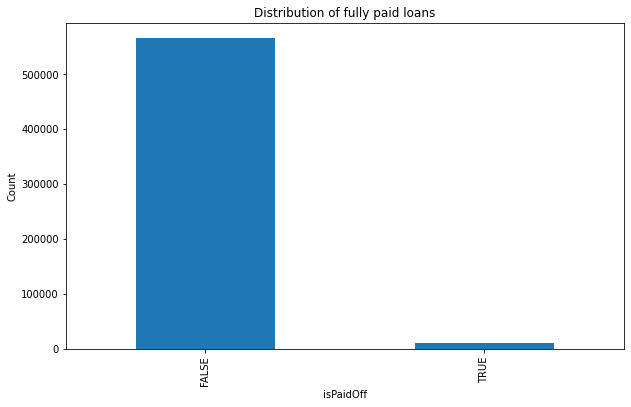

```python
plt.figure(figsize=(10, 6))
loan_df['isPaidOff'].value_counts().plot(kind='bar')
plt.xlabel('isPaidOff')
plt.ylabel('Count')
plt.title('Distribution of fully paid loans')
plt.show()
```

```python
isPaidOff_counts = loan_df['isPaidOff'].value_counts()
print('isPaidOff count:\n', isPaidOff_counts)
```

```
isPaidOff count:
 FALSE    565069
TRUE      10826
Name: isPaidOff, dtype: int64
```

```python
loan_status_counts = loan_df['loanStatus'].value_counts()
print('loanStatus count: \n', loan_status_counts)
```

```
loanStatus count:
 Withdrawn Application          449826
Rejected                        84855
Paid Off Loan                   11422
External Collection             11320
New Loan                         8112
Internal Collection              5567
Returned Item                    1182
CSR Voided New Loan              1025
Settlement Paid Off               706
Credit Return Void                704
Customer Voided New Loan          504
Settled Bankruptcy                325
Pending Paid Off                  169
Charged Off Paid Off              160
Pending Application Fee             5
Pending Rescind                     4
Pending Application                 4
Voided New Loan                     2
Charged Off                         1
Customver Voided New Loan           1
Settlement Pending Paid Off         1
Name: loanStatus, dtype: int64
```

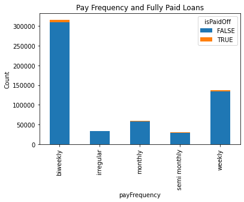

```python
# Calculate the counts of pay_on_time and late payments for each payFrequency
payment_counts = loan_df.groupby(['payFrequency', 'isPaidOff']).size().unstack()

# Sort the values within each payFrequency category in descending order
# payment_counts = payment_counts.apply(lambda x: x.sort_values(ascending=False), axis=1)

# Plot the stacked bar chart
payment_counts.plot(kind='bar', stacked=True)

# Add labels and title
plt.xlabel('payFrequency')
plt.ylabel('Count')
plt.title('Pay Frequency and Fully Paid Loans')

# Display the plot
plt.show()
```

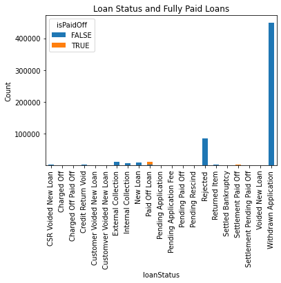

```python
status_counts = loan_df.groupby(['loanStatus', 'isPaidOff']).size().unstack()

# Sort the payment_counts DataFrame by the total count of pay_on_time in descending order
# status_counts = status_counts.sort_values(by=0, ascending=False)

# Plot the stacked bar chart
status_counts.plot(kind='bar', stacked=True)


# Add labels and title
plt.xlabel('loanStatus')
plt.ylabel('Count')
plt.title('Loan Status and Fully Paid Loans')

# Show the plot
plt.show()
```

### Integration with clarity_underwriting_variables.csv

```python
clarity_missing_values = clarity_df.isnull().sum()
print("missing values in clarity_underwriting_variables.csv: ")
print(clarity_missing_values)
```

```
missing values in clarity_underwriting_variables.csv:
.underwritingdataclarity.clearfraud.clearfraudinquiry.thirtydaysago                                        2
.underwritingdataclarity.clearfraud.clearfraudinquiry.twentyfourhoursago                                   2
.underwritingdataclarity.clearfraud.clearfraudinquiry.oneminuteago                                         2
.underwritingdataclarity.clearfraud.clearfraudinquiry.onehourago                                           2
.underwritingdataclarity.clearfraud.clearfraudinquiry.ninetydaysago                                        2
.underwritingdataclarity.clearfraud.clearfraudinquiry.sevendaysago                                         2
.underwritingdataclarity.clearfraud.clearfraudinquiry.tenminutesago                                        2
.underwritingdataclarity.clearfraud.clearfraudinquiry.fifteendaysago                                       2
.underwritingdataclarity.clearfraud.clearfraudinquiry.threesixtyfivedaysago                                2
.underwritingdataclarity.clearfraud.clearfraudindicator.inquiryonfilecurrentaddressconflict               40
.underwritingdataclarity.clearfraud.clearfraudindicator.totalnumberoffraudindicators                      17
.underwritingdataclarity.clearfraud.clearfraudindicator.telephonenumberinconsistentwithaddress            40
.underwritingdataclarity.clearfraud.clearfraudindicator.inquiryageyoungerthanssnissuedate                 40
.underwritingdataclarity.clearfraud.clearfraudindicator.onfileaddresscautious                             40
.underwritingdataclarity.clearfraud.clearfraudindicator.inquiryaddressnonresidential                      40
.underwritingdataclarity.clearfraud.clearfraudindicator.onfileaddresshighrisk                             40
.underwritingdataclarity.clearfraud.clearfraudindicator.ssnreportedmorefrequentlyforanother               40
.underwritingdataclarity.clearfraud.clearfraudindicator.currentaddressreportedbytradeopenlt90days         40
.underwritingdataclarity.clearfraud.clearfraudindicator.inputssninvalid                                   40
.underwritingdataclarity.clearfraud.clearfraudindicator.inputssnissuedatecannotbeverified                 40
.underwritingdataclarity.clearfraud.clearfraudindicator.inquiryaddresscautious                            40
.underwritingdataclarity.clearfraud.clearfraudindicator.morethan3inquiriesinthelast30days                 40
.underwritingdataclarity.clearfraud.clearfraudindicator.onfileaddressnonresidential                       40
.underwritingdataclarity.clearfraud.clearfraudindicator.creditestablishedpriortossnissuedate              40
.underwritingdataclarity.clearfraud.clearfraudindicator.driverlicenseformatinvalid                      5049
.underwritingdataclarity.clearfraud.clearfraudindicator.inputssnrecordedasdeceased                        40
.underwritingdataclarity.clearfraud.clearfraudindicator.inquiryaddresshighrisk                            40
.underwritingdataclarity.clearfraud.clearfraudindicator.inquirycurrentaddressnotonfile                    40
.underwritingdataclarity.clearfraud.clearfraudindicator.bestonfilessnissuedatecannotbeverified            40
.underwritingdataclarity.clearfraud.clearfraudindicator.highprobabilityssnbelongstoanother                40
.underwritingdataclarity.clearfraud.clearfraudindicator.maxnumberofssnswithanybankaccount                 17
.underwritingdataclarity.clearfraud.clearfraudindicator.bestonfilessnrecordedasdeceased                   40
.underwritingdataclarity.clearfraud.clearfraudindicator.currentaddressreportedbynewtradeonly              40
.underwritingdataclarity.clearfraud.clearfraudindicator.creditestablishedbeforeage18                      40
.underwritingdataclarity.clearfraud.clearfraudindicator.telephonenumberinconsistentwithstate             681
.underwritingdataclarity.clearfraud.clearfraudindicator.driverlicenseinconsistentwithonfile            39697
.underwritingdataclarity.clearfraud.clearfraudindicator.workphonepreviouslylistedascellphone           28336
.underwritingdataclarity.clearfraud.clearfraudindicator.workphonepreviouslylistedashomephone           28336
.underwritingdataclarity.clearfraud.clearfraudidentityverification.ssnnamematch                           32
.underwritingdataclarity.clearfraud.clearfraudidentityverification.nameaddressmatch                       32
.underwritingdataclarity.clearfraud.clearfraudidentityverification.phonematchtype                        953
.underwritingdataclarity.clearfraud.clearfraudidentityverification.ssnnamereasoncodedescription        47083
.underwritingdataclarity.clearfraud.clearfraudidentityverification.phonematchresult                       40
.underwritingdataclarity.clearfraud.clearfraudidentityverification.nameaddressreasoncodedescription    44125
.underwritingdataclarity.clearfraud.clearfraudidentityverification.phonematchtypedescription             953
.underwritingdataclarity.clearfraud.clearfraudidentityverification.overallmatchresult                     32
.underwritingdataclarity.clearfraud.clearfraudidentityverification.phonetype                           48237
.underwritingdataclarity.clearfraud.clearfraudidentityverification.ssndobreasoncode                    40723
.underwritingdataclarity.clearfraud.clearfraudidentityverification.ssnnamereasoncode                   47083
.underwritingdataclarity.clearfraud.clearfraudidentityverification.nameaddressreasoncode               44125
.underwritingdataclarity.clearfraud.clearfraudidentityverification.ssndobmatch                            32
.underwritingdataclarity.clearfraud.clearfraudidentityverification.overallmatchreasoncode                 32
clearfraudscore                                                                                          137
underwritingid                                                                                             0
dtype: int64
```

```python
#remove rows with missing values in clearfraudscore
clarity_df = clarity_df.dropna(subset=['clearfraudscore'])
#reset index
clarity_df = clarity_df.reset_index(drop=True)
```

Since all the columns started with `.underwritingdataclarity.clearfraud` indicating difference fraud indicators, :

- remove first portion of column name to make the name shorter

```python
#get existing column names
existing_columns = clarity_df.columns

#function to extract the relevant part of the column name

def extract_new_name(column_name):
    return column_name.split(".underwritingdataclarity.clearfraud.")[-1] #extracting last part of the split string, which represents the new column name

#rename the new column using the created function
new_columns = [extract_new_name(column) for column in existing_columns]

#create dictionary to map the existing columns
column_mapping = dict(zip(existing_columns, new_columns))

#rename the columns in clarity_df
clarity_df = clarity_df.rename(columns=column_mapping)

#display updated columns
print("Updated Columns in clarity_df: ")
clarity_df.head()
```

```
Updated Columns in clarity_df:
```

|  | clearfraudinquiry.thirtydaysago | clearfraudinquiry.twentyfourhoursago | clearfraudinquiry.oneminuteago | clearfraudinquiry.onehourago | clearfraudinquiry.ninetydaysago | clearfraudinquiry.sevendaysago | clearfraudinquiry.tenminutesago | clearfraudinquiry.fifteendaysago | clearfraudinquiry.threesixtyfivedaysago | clearfraudindicator.inquiryonfilecurrentaddressconflict | ... | clearfraudidentityverification.phonematchtypedescription | clearfraudidentityverification.overallmatchresult | clearfraudidentityverification.phonetype | clearfraudidentityverification.ssndobreasoncode | clearfraudidentityverification.ssnnamereasoncode | clearfraudidentityverification.nameaddressreasoncode | clearfraudidentityverification.ssndobmatch | clearfraudidentityverification.overallmatchreasoncode | clearfraudscore | underwritingid |
| --- | --- | --- | --- | --- | --- | --- | --- | --- | --- | --- | --- | --- | --- | --- | --- | --- | --- | --- | --- | --- | --- |
| 0 | 8.0 | 2.0 | 2.0 | 2.0 | 8.0 | 2.0 | 2.0 | 5.0 | 10.0 | False | ... | (M) Mobile Phone | partial | NaN | NaN | NaN | A8 | match | 6.0 | 871.0 | 54cbffcee4b0ba763e43144d |
| 1 | 5.0 | 2.0 | 2.0 | 2.0 | 11.0 | 2.0 | 2.0 | 4.0 | 21.0 | True | ... | (M) Mobile Phone | partial | NaN | NaN | NaN | NaN | match | 11.0 | 397.0 | 54cc0408e4b0418d9a7f78af |
| 2 | 9.0 | 4.0 | 2.0 | 3.0 | 10.0 | 8.0 | 2.0 | 9.0 | 25.0 | False | ... | (M) Mobile Phone | match | NaN | NaN | NaN | NaN | match | 1.0 | 572.0 | 54cc0683e4b0418d9a80adb6 |
| 3 | 3.0 | 2.0 | 2.0 | 2.0 | 9.0 | 2.0 | 2.0 | 2.0 | 9.0 | False | ... | (M) Mobile Phone | partial | NaN | NaN | NaN | NaN | match | 11.0 | 838.0 | 54cc0780e4b0ba763e43b74a |
| 4 | 5.0 | 5.0 | 2.0 | 2.0 | 6.0 | 5.0 | 2.0 | 5.0 | 6.0 | False | ... | (M) Mobile Phone | match | NaN | NaN | NaN | NaN | match | 1.0 | 768.0 | 54cc1d67e4b0ba763e445b45 |

5 rows × 54 columns

merge loan_df and clarity_df.

- we want to find loans that have fraud score provided by Clarity. Therefore, we used 'inner' join

```python
loan_clarity_df = loan_df.merge(clarity_df, left_on='clarityFraudId',
                           right_on='underwritingid', how='inner')

loan_clarity_df
```

|  | loanId | anon_ssn | payFrequency | apr | applicationDate | originated | originatedDate | nPaidOff | approved | isFunded | ... | clearfraudidentityverification.phonematchtypedescription | clearfraudidentityverification.overallmatchresult | clearfraudidentityverification.phonetype | clearfraudidentityverification.ssndobreasoncode | clearfraudidentityverification.ssnnamereasoncode | clearfraudidentityverification.nameaddressreasoncode | clearfraudidentityverification.ssndobmatch | clearfraudidentityverification.overallmatchreasoncode | clearfraudscore | underwritingid |
| --- | --- | --- | --- | --- | --- | --- | --- | --- | --- | --- | --- | --- | --- | --- | --- | --- | --- | --- | --- | --- | --- |
| 0 | LL-I-06644937 | 464f5d9ae4fa09ece4048d949191865c | biweekly | 199.0 | 2016-01-19T22:07:36.778000 | True | 2016-01-20T15:49:18.846000 | 0.0 | True | 1 | ... | NaN | partial | NaN | D04 | NaN | NaN | invalid | 5.0 | 879.0 | 569eb3a3e4b096699f685d64 |
| 1 | LL-I-17826953 | 7529d29c9d943cc55bc71a85d9c6b7a3 | weekly | 645.0 | 2017-03-01T15:55:41.823000 | True | 2017-03-01T16:15:13.016000 | 0.0 | True | 1 | ... | (U) Unlisted | match | NaN | NaN | NaN | NaN | match | 1.0 | 658.0 | 58b6eef8e4b0b6fca82fd426 |
| 2 | LL-I-16519347 | bc9fa73468acf18cb968a3a6a3c4697c | semi monthly | 490.0 | 2017-01-31T17:48:17.381000 | True | 2017-01-31T18:00:14.520000 | 2.0 | True | 1 | ... | (M) Mobile Phone | partial | NaN | NaN | NaN | A8 | match | 6.0 | 835.0 | 58450a15e4b0bb9d6d7344c7 |
| 3 | LL-I-17491287 | bc9fa73468acf18cb968a3a6a3c4697c | semi monthly | 490.0 | 2017-02-21T17:20:23.671000 | True | 2017-02-21T17:45:11.088000 | 3.0 | True | 1 | ... | (M) Mobile Phone | partial | NaN | NaN | NaN | A8 | match | 6.0 | 835.0 | 58450a15e4b0bb9d6d7344c7 |
| 4 | LL-I-15679301 | bc9fa73468acf18cb968a3a6a3c4697c | semi monthly | 490.0 | 2017-01-18T01:16:24.941000 | True | 2017-01-18T01:30:16.712000 | 1.0 | True | 1 | ... | (M) Mobile Phone | partial | NaN | NaN | NaN | A8 | match | 6.0 | 835.0 | 58450a15e4b0bb9d6d7344c7 |
| ... | ... | ... | ... | ... | ... | ... | ... | ... | ... | ... | ... | ... | ... | ... | ... | ... | ... | ... | ... | ... | ... |
| 36094 | LL-I-17508871 | f0b666fdd1b46c58297b3828b61047ad | monthly | 180.2 | 2017-02-21T20:29:57.538000 | True | 2017-02-21T20:45:06.563000 | 0.0 | True | 1 | ... | (M) Mobile Phone | partial | NaN | NaN | NaN | NaN | match | 16.0 | 695.0 | 58aca342e4b0bf804c0e82db |
| 36095 | LL-I-15280684 | 73690518af906288434b2a0cfd972fe0 | monthly | 645.0 | 2017-01-14T19:43:08.685000 | True | 2017-01-14T20:00:10.426000 | 0.0 | True | 1 | ... | (M) Mobile Phone | match | NaN | NaN | NaN | NaN | match | 1.0 | 700.0 | 587a7f49e4b08f2485d48358 |
| 36096 | LL-I-09897110 | 0538f828b4a0b44502ead5a8033ee779 | biweekly | 449.0 | 2016-06-22T01:10:50.110000 | True | 2016-06-22T21:46:54.359000 | 0.0 | True | 1 | ... | (M) Mobile Phone | partial | NaN | NaN | NaN | NaN | match | 11.0 | 806.0 | 5769e592e4b0ab6c50364d45 |
| 36097 | LL-I-14178923 | d9a63e9e15b862fcaaf3653c52e1f16c | biweekly | 625.0 | 2016-12-30T15:49:39.785000 | True | 2016-12-30T16:00:12.500000 | 0.0 | True | 1 | ... | (M) Mobile Phone | partial | NaN | NaN | NaN | NaN | match | 11.0 | 769.0 | 58668211e4b08f246e282356 |
| 36098 | LL-I-13311312 | 043dd86c24c63c8968082fa3ad7a8911 | weekly | 645.0 | 2016-12-16T20:20:30.157000 | True | 2016-12-16T23:15:06.874000 | 0.0 | True | 1 | ... | (M) Mobile Phone | partial | NaN | NaN | NaN | NaN | match | 16.0 | 827.0 | 5840ad86e4b0bb9d6980127f |

36099 rows × 75 columns

# Clarity Data

3 new features can be created from this data that can be useful in identifying loan risk and predicting loan quality.

1. fraud_indicator_flags
2. fraud_inquiry_flags
3. fraud_identity_verification_flags

`Explanation for each features:`

fraud_indicator_flags:

- since most of the columns contain 'TRUE' or 'FALSE'. Replace the value with 1 for TRUE, 0 for FALSE
- Total up the number of total fraud indicator
- Higher number in 'fraud_indicator_flags means high fraudulent activities reported by clarity

fraud_enquiry_flags:

- how many fraud enquiries seen by clarity for that underwritingid

fraud_identity_verification_flags:

- see if ssnnamematch?
- name address match?
- phonematchtype?
- drop verification.phonetype, ssndobreasoncode, ssnnamereasoncode, nameaddresscode, nameaddressresoncodedescription (these column can be use for analysis but not for model prediction)
- change match, mismatch, partial to numbers such as 0 ,1 ,2
- add up identity verification flags: more flags meaning higher probability of fraud/identity theft

```python
fraud_indicators = [
    'clearfraudindicator.inquiryonfilecurrentaddressconflict',
    'clearfraudindicator.telephonenumberinconsistentwithaddress',
    'clearfraudindicator.inquiryageyoungerthanssnissuedate',
    'clearfraudindicator.onfileaddresscautious',
    'clearfraudindicator.inquiryaddressnonresidential',
    'clearfraudindicator.onfileaddresshighrisk',
    'clearfraudindicator.ssnreportedmorefrequentlyforanother',
    'clearfraudindicator.currentaddressreportedbytradeopenlt90days',
    'clearfraudindicator.inputssninvalid',
    'clearfraudindicator.inputssnissuedatecannotbeverified',
    'clearfraudindicator.inquiryaddresscautious',
    'clearfraudindicator.morethan3inquiriesinthelast30days',
    'clearfraudindicator.onfileaddressnonresidential',
    'clearfraudindicator.creditestablishedpriortossnissuedate',
    'clearfraudindicator.driverlicenseformatinvalid',
    'clearfraudindicator.inputssnrecordedasdeceased',
    'clearfraudindicator.inquiryaddresshighrisk',
    'clearfraudindicator.inquirycurrentaddressnotonfile',
    'clearfraudindicator.bestonfilessnissuedatecannotbeverified',
    'clearfraudindicator.highprobabilityssnbelongstoanother',
    'clearfraudindicator.bestonfilessnrecordedasdeceased',
    'clearfraudindicator.currentaddressreportedbynewtradeonly',
    'clearfraudindicator.creditestablishedbeforeage18',
    'clearfraudindicator.telephonenumberinconsistentwithstate',
    'clearfraudindicator.driverlicenseinconsistentwithonfile',
    'clearfraudindicator.workphonepreviouslylistedascellphone',
    'clearfraudindicator.workphonepreviouslylistedashomephone',
]

loan_clarity_df[fraud_indicators]
```

|  | clearfraudindicator.inquiryonfilecurrentaddressconflict | clearfraudindicator.telephonenumberinconsistentwithaddress | clearfraudindicator.inquiryageyoungerthanssnissuedate | clearfraudindicator.onfileaddresscautious | clearfraudindicator.inquiryaddressnonresidential | clearfraudindicator.onfileaddresshighrisk | clearfraudindicator.ssnreportedmorefrequentlyforanother | clearfraudindicator.currentaddressreportedbytradeopenlt90days | clearfraudindicator.inputssninvalid | clearfraudindicator.inputssnissuedatecannotbeverified | ... | clearfraudindicator.inquirycurrentaddressnotonfile | clearfraudindicator.bestonfilessnissuedatecannotbeverified | clearfraudindicator.highprobabilityssnbelongstoanother | clearfraudindicator.bestonfilessnrecordedasdeceased | clearfraudindicator.currentaddressreportedbynewtradeonly | clearfraudindicator.creditestablishedbeforeage18 | clearfraudindicator.telephonenumberinconsistentwithstate | clearfraudindicator.driverlicenseinconsistentwithonfile | clearfraudindicator.workphonepreviouslylistedascellphone | clearfraudindicator.workphonepreviouslylistedashomephone |
| --- | --- | --- | --- | --- | --- | --- | --- | --- | --- | --- | --- | --- | --- | --- | --- | --- | --- | --- | --- | --- | --- |
| 0 | False | False | False | False | False | False | False | False | False | False | ... | False | False | False | False | False | False | NaN | NaN | False | False |
| 1 | True | True | False | False | True | False | False | False | False | False | ... | True | False | False | False | False | False | False | NaN | NaN | NaN |
| 2 | False | True | False | False | False | False | False | False | False | False | ... | False | False | False | False | False | False | False | NaN | NaN | NaN |
| 3 | False | True | False | False | False | False | False | False | False | False | ... | False | False | False | False | False | False | False | NaN | NaN | NaN |
| 4 | False | True | False | False | False | False | False | False | False | False | ... | False | False | False | False | False | False | False | NaN | NaN | NaN |
| ... | ... | ... | ... | ... | ... | ... | ... | ... | ... | ... | ... | ... | ... | ... | ... | ... | ... | ... | ... | ... | ... |
| 36094 | False | True | False | False | False | False | False | False | False | False | ... | False | False | False | False | True | False | False | NaN | NaN | NaN |
| 36095 | False | True | False | False | True | False | False | False | False | False | ... | False | False | False | False | False | False | False | NaN | NaN | NaN |
| 36096 | True | True | False | False | False | False | False | False | False | False | ... | False | False | False | False | False | False | True | NaN | False | False |
| 36097 | True | True | False | False | False | False | False | False | False | False | ... | False | False | False | False | False | False | False | NaN | NaN | NaN |
| 36098 | False | True | False | False | False | False | False | True | False | False | ... | False | False | False | False | False | False | False | NaN | NaN | NaN |

36099 rows × 27 columns

```python
#convert boolean values (True/False) to 1 and 0
loan_clarity_df[fraud_indicators] = loan_clarity_df[fraud_indicators].fillna(False).astype(int)

#add new column in dataframe
loan_clarity_df['fraud_indicator_flags'] = loan_clarity_df[fraud_indicators].sum(axis=1)

columns = [
    'underwritingid',
    'clearfraudindicator.bestonfilessnissuedatecannotbeverified',
    'clearfraudindicator.bestonfilessnrecordedasdeceased',
    'clearfraudindicator.creditestablishedbeforeage18',
    'clearfraudindicator.creditestablishedpriortossnissuedate',
    'clearfraudindicator.currentaddressreportedbynewtradeonly',
    'clearfraudindicator.currentaddressreportedbytradeopenlt90days',
    'clearfraudindicator.driverlicenseformatinvalid',
    'clearfraudindicator.driverlicenseinconsistentwithonfile',
    'clearfraudindicator.inputssnissuedatecannotbeverified',
    'clearfraudindicator.inputssnrecordedasdeceased',
    'clearfraudindicator.inputssninvalid',
    'clearfraudindicator.inquiryaddresscautious',
    'clearfraudindicator.inquiryaddresshighrisk',
    'clearfraudindicator.inquiryaddressnonresidential',
    'clearfraudindicator.inquiryageyoungerthanssnissuedate',
    'clearfraudindicator.inquirycurrentaddressnotonfile',
    'clearfraudindicator.morethan3inquiriesinthelast30days',
    'clearfraudindicator.inquiryonfilecurrentaddressconflict',
    'clearfraudindicator.maxnumberofssnswithanybankaccount',
    'clearfraudindicator.onfileaddresscautious',
    'clearfraudindicator.onfileaddresshighrisk',
    'clearfraudindicator.onfileaddressnonresidential',
    'clearfraudindicator.telephonenumberinconsistentwithaddress',
    'clearfraudindicator.telephonenumberinconsistentwithstate',
    'clearfraudindicator.highprobabilityssnbelongstoanother',
    'clearfraudindicator.ssnreportedmorefrequentlyforanother',
    'fraud_indicator_flags'
]
loan_clarity_df[columns]
```

|  | underwritingid | clearfraudindicator.bestonfilessnissuedatecannotbeverified | clearfraudindicator.bestonfilessnrecordedasdeceased | clearfraudindicator.creditestablishedbeforeage18 | clearfraudindicator.creditestablishedpriortossnissuedate | clearfraudindicator.currentaddressreportedbynewtradeonly | clearfraudindicator.currentaddressreportedbytradeopenlt90days | clearfraudindicator.driverlicenseformatinvalid | clearfraudindicator.driverlicenseinconsistentwithonfile | clearfraudindicator.inputssnissuedatecannotbeverified | ... | clearfraudindicator.inquiryonfilecurrentaddressconflict | clearfraudindicator.maxnumberofssnswithanybankaccount | clearfraudindicator.onfileaddresscautious | clearfraudindicator.onfileaddresshighrisk | clearfraudindicator.onfileaddressnonresidential | clearfraudindicator.telephonenumberinconsistentwithaddress | clearfraudindicator.telephonenumberinconsistentwithstate | clearfraudindicator.highprobabilityssnbelongstoanother | clearfraudindicator.ssnreportedmorefrequentlyforanother | fraud_indicator_flags |
| --- | --- | --- | --- | --- | --- | --- | --- | --- | --- | --- | --- | --- | --- | --- | --- | --- | --- | --- | --- | --- | --- |
| 0 | 569eb3a3e4b096699f685d64 | 0 | 0 | 0 | 0 | 0 | 0 | 0 | 0 | 0 | ... | 0 | 1.0 | 0 | 0 | 0 | 0 | 0 | 0 | 0 | 0 |
| 1 | 58b6eef8e4b0b6fca82fd426 | 0 | 0 | 0 | 0 | 0 | 0 | 0 | 0 | 0 | ... | 1 | 1.0 | 0 | 0 | 1 | 1 | 0 | 0 | 0 | 5 |
| 2 | 58450a15e4b0bb9d6d7344c7 | 0 | 0 | 0 | 0 | 0 | 0 | 0 | 0 | 0 | ... | 0 | 2.0 | 0 | 0 | 0 | 1 | 0 | 0 | 0 | 1 |
| 3 | 58450a15e4b0bb9d6d7344c7 | 0 | 0 | 0 | 0 | 0 | 0 | 0 | 0 | 0 | ... | 0 | 2.0 | 0 | 0 | 0 | 1 | 0 | 0 | 0 | 1 |
| 4 | 58450a15e4b0bb9d6d7344c7 | 0 | 0 | 0 | 0 | 0 | 0 | 0 | 0 | 0 | ... | 0 | 2.0 | 0 | 0 | 0 | 1 | 0 | 0 | 0 | 1 |
| ... | ... | ... | ... | ... | ... | ... | ... | ... | ... | ... | ... | ... | ... | ... | ... | ... | ... | ... | ... | ... | ... |
| 36094 | 58aca342e4b0bf804c0e82db | 0 | 0 | 0 | 0 | 1 | 0 | 0 | 0 | 0 | ... | 0 | 2.0 | 0 | 0 | 0 | 1 | 0 | 0 | 0 | 2 |
| 36095 | 587a7f49e4b08f2485d48358 | 0 | 0 | 0 | 0 | 0 | 0 | 0 | 0 | 0 | ... | 0 | 2.0 | 0 | 0 | 0 | 1 | 0 | 0 | 0 | 2 |
| 36096 | 5769e592e4b0ab6c50364d45 | 0 | 0 | 0 | 0 | 0 | 0 | 1 | 0 | 0 | ... | 1 | 1.0 | 0 | 0 | 0 | 1 | 1 | 0 | 0 | 4 |
| 36097 | 58668211e4b08f246e282356 | 0 | 0 | 0 | 0 | 0 | 0 | 0 | 0 | 0 | ... | 1 | 1.0 | 0 | 0 | 0 | 1 | 0 | 0 | 0 | 2 |
| 36098 | 5840ad86e4b0bb9d6980127f | 0 | 0 | 0 | 0 | 0 | 1 | 0 | 0 | 0 | ... | 0 | 1.0 | 0 | 0 | 0 | 1 | 0 | 0 | 0 | 3 |

36099 rows × 28 columns

```python
fraud_inquiry_columns = [
    'clearfraudinquiry.onehourago',
    'clearfraudinquiry.oneminuteago',
    'clearfraudinquiry.tenminutesago',
    'clearfraudinquiry.fifteendaysago',
    'clearfraudinquiry.twentyfourhoursago',
    'clearfraudinquiry.thirtydaysago',
    'clearfraudinquiry.threesixtyfivedaysago',
    'clearfraudinquiry.sevendaysago',
    'clearfraudinquiry.ninetydaysago'
]

#fill null values as 0
loan_clarity_df[fraud_inquiry_columns] = loan_clarity_df[fraud_inquiry_columns].fillna(0).astype(int)

#create 'fraud_enquiry_flags' column
loan_clarity_df['fraud_enquiry_flags'] = loan_clarity_df[fraud_inquiry_columns].sum(axis=1)

#view dataframe
loan_clarity_df[['loanId','loanStatus','clearfraudscore','fraud_enquiry_flags', 'fraud_enquiry_flags']]
```

|  | loanId | loanStatus | clearfraudscore | fraud_enquiry_flags | fraud_enquiry_flags |
| --- | --- | --- | --- | --- | --- |
| 0 | LL-I-06644937 | Paid Off Loan | 879.0 | 28 | 28 |
| 1 | LL-I-17826953 | New Loan | 658.0 | 27 | 27 |
| 2 | LL-I-16519347 | Paid Off Loan | 835.0 | 37 | 37 |
| 3 | LL-I-17491287 | Paid Off Loan | 835.0 | 37 | 37 |
| 4 | LL-I-15679301 | Paid Off Loan | 835.0 | 37 | 37 |
| ... | ... | ... | ... | ... | ... |
| 36094 | LL-I-17508871 | Returned Item | 695.0 | 27 | 27 |
| 36095 | LL-I-15280684 | Paid Off Loan | 700.0 | 30 | 30 |
| 36096 | LL-I-09897110 | Paid Off Loan | 806.0 | 31 | 31 |
| 36097 | LL-I-14178923 | New Loan | 769.0 | 34 | 34 |
| 36098 | LL-I-13311312 | Paid Off Loan | 827.0 | 17 | 17 |

36099 rows × 5 columns

```python
identity_verification_columns = [
    'clearfraudidentityverification.ssnnamematch',
    'clearfraudidentityverification.nameaddressmatch',
    'clearfraudidentityverification.phonematchresult',
    'clearfraudidentityverification.overallmatchresult',
    'clearfraudidentityverification.ssndobmatch',
]
```

Steps for this operation:

- for each column, i created a temp column with a name like 'temp_clearfraudidentityverification.ssnnamematch'
- due to issuficient time, the missing value in the original column will be assigned as 'match'
- compare values in temp column with 'match' and convert the matches to 0, and other criteria (mismatch, unavailable, partial, invalid) to 1
- calculate sum of the temp column across the rows to get the total flags for each loan record
- assigned the total flags to the new column 'fraud_identity_verification_flags'
- remove temp columns to retain the original column
- The `'fraud_identity_verification_flags'` column represents the total number of flags in the fraud identity verification columns. A higher value in this column indicates a higher risk of defaulting.

```python
for column in identity_verification_columns:
    temp_column = f"temp_{column}"
    loan_clarity_df[temp_column] = loan_clarity_df[column].fillna('match')
    loan_clarity_df[temp_column] = (loan_clarity_df[temp_column] != 'match').astype(int)

loan_clarity_df['fraud_identity_verification_flags'] = loan_clarity_df[
    [f"temp_{column}" for column in identity_verification_columns]
].sum(axis=1)

loan_clarity_df = loan_clarity_df.drop([f"temp_{column}" for column in identity_verification_columns], axis=1)
```

```python
loan_clarity_df[['underwritingid',
                'clearfraudidentityverification.ssnnamematch',
                'clearfraudidentityverification.nameaddressmatch',
                'clearfraudidentityverification.phonematchresult',
                'clearfraudidentityverification.overallmatchresult',
                'clearfraudidentityverification.ssndobmatch',
                'fraud_identity_verification_flags',
                'clearfraudscore']]
```

|  | underwritingid | clearfraudidentityverification.ssnnamematch | clearfraudidentityverification.nameaddressmatch | clearfraudidentityverification.phonematchresult | clearfraudidentityverification.overallmatchresult | clearfraudidentityverification.ssndobmatch | fraud_identity_verification_flags | clearfraudscore |
| --- | --- | --- | --- | --- | --- | --- | --- | --- |
| 0 | 569eb3a3e4b096699f685d64 | match | match | invalid | partial | invalid | 3 | 879.0 |
| 1 | 58b6eef8e4b0b6fca82fd426 | match | match | unavailable | match | match | 1 | 658.0 |
| 2 | 58450a15e4b0bb9d6d7344c7 | match | partial | unavailable | partial | match | 3 | 835.0 |
| 3 | 58450a15e4b0bb9d6d7344c7 | match | partial | unavailable | partial | match | 3 | 835.0 |
| 4 | 58450a15e4b0bb9d6d7344c7 | match | partial | unavailable | partial | match | 3 | 835.0 |
| ... | ... | ... | ... | ... | ... | ... | ... | ... |
| 36094 | 58aca342e4b0bf804c0e82db | match | unavailable | unavailable | partial | match | 3 | 695.0 |
| 36095 | 587a7f49e4b08f2485d48358 | match | match | unavailable | match | match | 1 | 700.0 |
| 36096 | 5769e592e4b0ab6c50364d45 | match | mismatch | unavailable | partial | match | 3 | 806.0 |
| 36097 | 58668211e4b08f246e282356 | match | mismatch | unavailable | partial | match | 3 | 769.0 |
| 36098 | 5840ad86e4b0bb9d6980127f | match | unavailable | unavailable | partial | match | 3 | 827.0 |

36099 rows × 8 columns

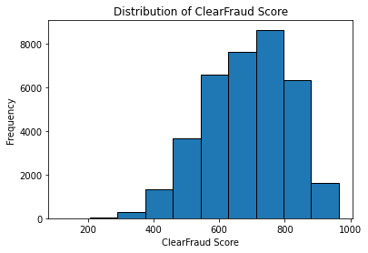

```python
import matplotlib.pyplot as plt

# Plotting histogram
plt.hist(loan_clarity_df['clearfraudscore'], bins=10, edgecolor='black')

# Adding labels and title
plt.xlabel('ClearFraud Score')
plt.ylabel('Frequency')
plt.title('Distribution of ClearFraud Score')

# Displaying the histogram
plt.show()
```

```python
loan_clarity_df['clearfraudscore'].describe()
```

```
count    36099.000000
mean       687.312252
std        127.039853
min        122.000000
25%        596.000000
50%        695.000000
75%        787.000000
max        965.000000
Name: clearfraudscore, dtype: float64
```

From this knowledge, we can create another column that can potentially become our target variable called 'loan_risk'. we divide the range into 3 risk levels: high risk, medium risk, and low risk.

- based on the distribution, we can set each risks based on the percentile value from the distribution
- high risk: scores below 600 (approximately the 25th percentile)
- medium risk: score between 600 and 800 (25th percentile to 75th percentile)
- low risk: scores above 800 (approximately 75th percentile)

```python
# Define the threshold values
thresholds = [0, 600, 800, float('inf')]
risk_labels = ['High Risk', 'Medium Risk', 'Low Risk']

# Assign risk levels using cut()
loan_clarity_df['loan_risk'] = pd.cut(loan_clarity_df['clearfraudscore'], bins=thresholds, labels=risk_labels)
```

```python
loan_clarity_df[['loanId', 'loanStatus', 'clearfraudscore','loan_risk']]
```

|  | loanId | loanStatus | clearfraudscore | loan_risk |
| --- | --- | --- | --- | --- |
| 0 | LL-I-06644937 | Paid Off Loan | 879.0 | Low Risk |
| 1 | LL-I-17826953 | New Loan | 658.0 | Medium Risk |
| 2 | LL-I-16519347 | Paid Off Loan | 835.0 | Low Risk |
| 3 | LL-I-17491287 | Paid Off Loan | 835.0 | Low Risk |
| 4 | LL-I-15679301 | Paid Off Loan | 835.0 | Low Risk |
| ... | ... | ... | ... | ... |
| 36094 | LL-I-17508871 | Returned Item | 695.0 | Medium Risk |
| 36095 | LL-I-15280684 | Paid Off Loan | 700.0 | Medium Risk |
| 36096 | LL-I-09897110 | Paid Off Loan | 806.0 | Low Risk |
| 36097 | LL-I-14178923 | New Loan | 769.0 | Medium Risk |
| 36098 | LL-I-13311312 | Paid Off Loan | 827.0 | Low Risk |

36099 rows × 4 columns

```python
print(loan_clarity_df['loan_risk'].value_counts())
```

```
Medium Risk    19150
High Risk       9395
Low Risk        7554
Name: loan_risk, dtype: int64
```

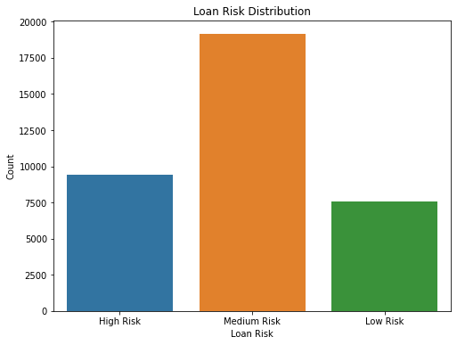

```python
loan_risk_counts = loan_clarity_df['loan_risk'].value_counts()
plt.figure(figsize=(8, 6))
sns.barplot(x=loan_risk_counts.index, y=loan_risk_counts.values)
plt.title('Loan Risk Distribution')
plt.xlabel('Loan Risk')
plt.ylabel('Count')
plt.show()
```

## Some Visualization

stacked bar chart for 'payFrequency' and 'loan_risk'

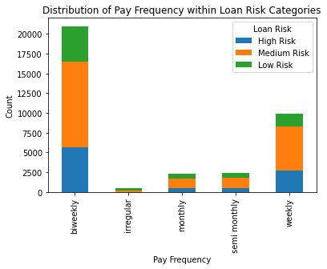

```python
loan_risk_counts = loan_clarity_df['loan_risk'].value_counts()
pay_freq_loan_risk = loan_clarity_df.groupby(['payFrequency', 'loan_risk']).size().unstack()

pay_freq_loan_risk.plot(kind='bar', stacked=True)
plt.xlabel('Pay Frequency')
plt.ylabel('Count')
plt.title('Distribution of Pay Frequency within Loan Risk Categories')
plt.legend(title='Loan Risk')
plt.show()
```

box plot for 'loanAmount' and 'loan_risk'

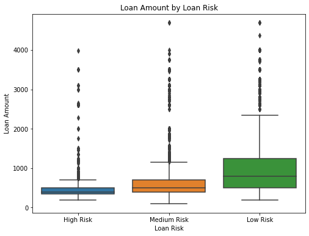

```python
plt.figure(figsize=(8, 6))
sns.boxplot(x='loan_risk', y='loanAmount', data=loan_clarity_df)
plt.title('Loan Amount by Loan Risk')
plt.xlabel('Loan Risk')
plt.ylabel('Loan Amount')
plt.show()
```

scatter plot for 'clearfraudscore' and 'total_principal_paid'

```python
# loan_clarity_df.to_csv('testing.csv')
```

scatterplot of total principal paid and clearfraud score

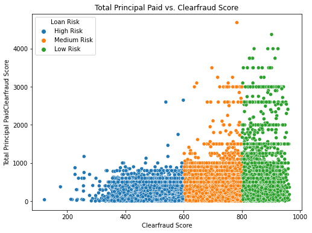

```python
plt.figure(figsize=(8, 6))
sns.scatterplot(x='clearfraudscore', y='total_principal_paid', hue='loan_risk', data=loan_clarity_df)
plt.title('Total Principal Paid vs. Clearfraud Score')
plt.xlabel('Clearfraud Score')
plt.ylabel('Total Principal PaidClearfraud Score')
plt.legend(title='Loan Risk')
plt.show()
```

loan amount distribution

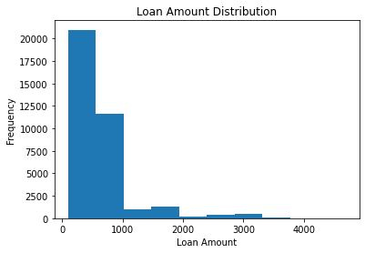

```python
plt.hist(loan_clarity_df['loanAmount'], bins=10)
plt.xlabel('Loan Amount')
plt.ylabel('Frequency')
plt.title('Loan Amount Distribution')
plt.show()
```

loan status proportions (Pie Chart)

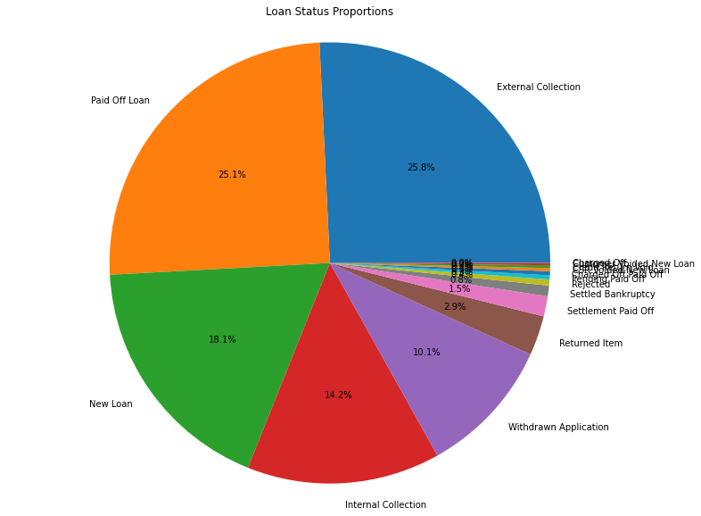

```python
plt.figure(figsize=(13, 10))
loan_status_counts = loan_clarity_df['loanStatus'].value_counts()
plt.pie(loan_status_counts, labels=loan_status_counts.index, autopct='%1.1f%%')
plt.title('Loan Status Proportions')
plt.axis('equal')
plt.show()
```

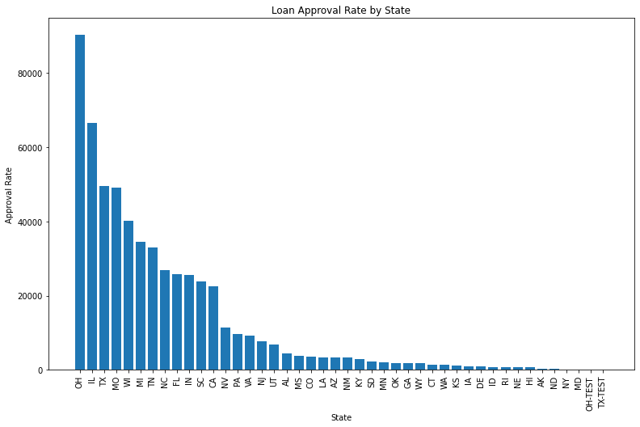

```python
loan_approval_rate_by_state = loan_df.groupby('state')['approved'].count().sort_values(ascending=False)
plt.figure(figsize=(13, 8))

plt.bar(loan_approval_rate_by_state.index, loan_approval_rate_by_state)
plt.xlabel('State')
plt.ylabel('Approval Rate')
plt.title('Loan Approval Rate by State')
plt.xticks(rotation=90)
plt.show()
```

Scatterplot of Loan Amount vs ClearFraudScore

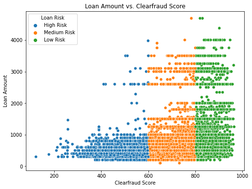

```python
plt.figure(figsize=(8, 6))
sns.scatterplot(x='clearfraudscore', y='loanAmount', hue='loan_risk', data=loan_clarity_df)
plt.title('Loan Amount vs. Clearfraud Score')
plt.xlabel('Clearfraud Score')
plt.ylabel('Loan Amount')
plt.legend(title='Loan Risk')
plt.show()
```

loan payments over time

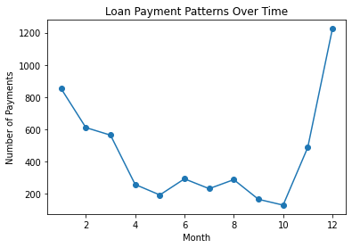

```python
loan_payment_df['originatedDate'] = pd.to_datetime(loan_df['originatedDate'])
loan_payment_df['month'] = loan_payment_df['originatedDate'].dt.month

loan_payments_by_month = loan_payment_df.groupby('month')['nPaidOff'].sum()
plt.plot(loan_payments_by_month.index, loan_payments_by_month, marker='o')
plt.xlabel('Month')
plt.ylabel('Number of Payments')
plt.title('Loan Payment Patterns Over Time')
plt.show()
```

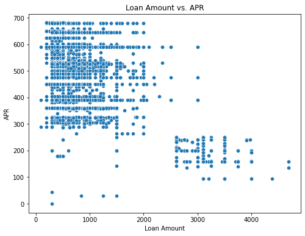

```python
plt.figure(figsize=(8, 6))
sns.scatterplot(x='loanAmount', y='apr', data=loan_clarity_df)
plt.title('Loan Amount vs. APR')
plt.xlabel('Loan Amount')
plt.ylabel('APR')
plt.show()
```

Loan risk Distribution by Pay Frequency

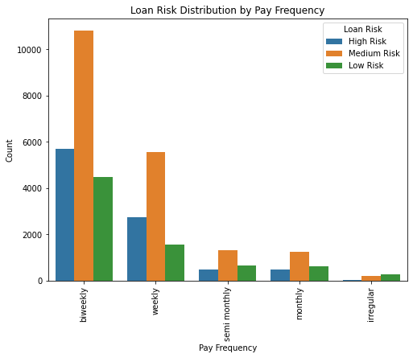

```python
plt.figure(figsize=(8, 6))
sns.countplot(x='payFrequency', hue='loan_risk', data=loan_clarity_df)
plt.xlabel('Pay Frequency')
plt.ylabel('Count')
plt.title('Loan Risk Distribution by Pay Frequency')
plt.legend(title='Loan Risk')
plt.xticks(rotation=90)
plt.show()
```

Loan Risk vs. Clear Fraud Score (Boxen Plot)

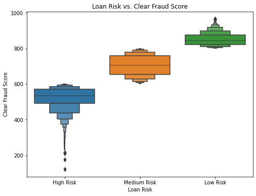

```python
plt.figure(figsize=(8, 6))
sns.boxenplot(x='loan_risk', y='clearfraudscore', data=loan_clarity_df)
plt.xlabel('Loan Risk')
plt.ylabel('Clear Fraud Score')
plt.title('Loan Risk vs. Clear Fraud Score')
plt.show()
```

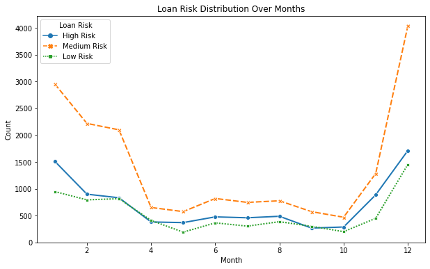

```python
loan_clarity_df['originatedDate'] = pd.to_datetime(loan_clarity_df['originatedDate'])
loan_clarity_df['month'] = loan_clarity_df['originatedDate'].dt.month

loan_risk_over_time = loan_clarity_df.groupby(['month', 'loan_risk']).size().unstack()

plt.figure(figsize=(10, 6))  # Set the figure size to be wider

sns.lineplot(data=loan_risk_over_time, markers=True, linewidth=2)
plt.xlabel('Month')
plt.ylabel('Count')
plt.title('Loan Risk Distribution Over Months')
plt.legend(title='Loan Risk')
plt.show()
```

Which States has the most low risk / high risk loans?

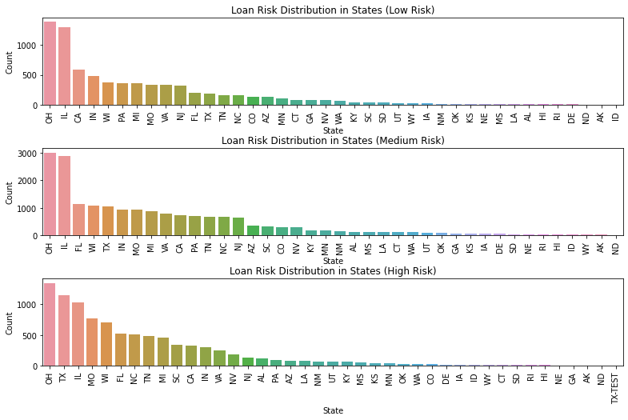

```python
# Count low risk and high risk loans by state
low_risk_states = loan_clarity_df[loan_clarity_df['loan_risk'] == 'Low Risk']['state'].value_counts()
medium_risk_states = loan_clarity_df[loan_clarity_df['loan_risk'] == 'Medium Risk']['state'].value_counts()
high_risk_states = loan_clarity_df[loan_clarity_df['loan_risk'] == 'High Risk']['state'].value_counts()

# Create a figure with two subplots
fig, (ax1, ax2, ax3) = plt.subplots(3, 1, figsize=(13, 8))

# Plot low risk loan distribution
sns.barplot(x=low_risk_states.index, y=low_risk_states.values, ax=ax1)
ax1.set_xlabel('State')
ax1.set_ylabel('Count')
ax1.set_title('Loan Risk Distribution in States (Low Risk)')
ax1.tick_params(axis='x', rotation=90)

# Plot medium risk loan distribution
sns.barplot(x=medium_risk_states.index, y=medium_risk_states.values, ax=ax2)
ax2.set_xlabel('State')
ax2.set_ylabel('Count')
ax2.set_title('Loan Risk Distribution in States (Medium Risk)')
ax2.tick_params(axis='x', rotation=90)

# Plot high risk loan distribution
sns.barplot(x=high_risk_states.index, y=high_risk_states.values, ax=ax3)
ax3.set_xlabel('State')
ax3.set_ylabel('Count')
ax3.set_title('Loan Risk Distribution in States (High Risk)')
ax3.tick_params(axis='x', rotation=90)

# Adjust spacing between subplots
plt.subplots_adjust(hspace=0.5)

# Display the combined chart
plt.show()
```

```python
#remove some columns used for visualization
loan_clarity_df = loan_clarity_df.drop(columns=['month'])
```

## Predict Loan Risk And Clear Fraud Score

```python
from sklearn.model_selection import train_test_split
from sklearn.ensemble import RandomForestClassifier
from sklearn.metrics import classification_report, confusion_matrix
from boruta import BorutaPy
from sklearn.preprocessing import LabelEncoder
```

Prepare the data

```python
loan_clarity_df.columns
```

```
Index(['loanId', 'anon_ssn', 'payFrequency', 'apr', 'applicationDate',
       'originated', 'originatedDate', 'nPaidOff', 'approved', 'isFunded',
       'loanStatus', 'loanAmount', 'originallyScheduledPaymentAmount', 'state',
       'leadType', 'leadCost', 'fpStatus', 'clarityFraudId', 'hasCF',
       'total_principal_paid', 'isPaidOff', 'clearfraudinquiry.thirtydaysago',
       'clearfraudinquiry.twentyfourhoursago',
       'clearfraudinquiry.oneminuteago', 'clearfraudinquiry.onehourago',
       'clearfraudinquiry.ninetydaysago', 'clearfraudinquiry.sevendaysago',
       'clearfraudinquiry.tenminutesago', 'clearfraudinquiry.fifteendaysago',
       'clearfraudinquiry.threesixtyfivedaysago',
       'clearfraudindicator.inquiryonfilecurrentaddressconflict',
       'clearfraudindicator.totalnumberoffraudindicators',
       'clearfraudindicator.telephonenumberinconsistentwithaddress',
       'clearfraudindicator.inquiryageyoungerthanssnissuedate',
       'clearfraudindicator.onfileaddresscautious',
       'clearfraudindicator.inquiryaddressnonresidential',
       'clearfraudindicator.onfileaddresshighrisk',
       'clearfraudindicator.ssnreportedmorefrequentlyforanother',
       'clearfraudindicator.currentaddressreportedbytradeopenlt90days',
       'clearfraudindicator.inputssninvalid',
       'clearfraudindicator.inputssnissuedatecannotbeverified',
       'clearfraudindicator.inquiryaddresscautious',
       'clearfraudindicator.morethan3inquiriesinthelast30days',
       'clearfraudindicator.onfileaddressnonresidential',
       'clearfraudindicator.creditestablishedpriortossnissuedate',
       'clearfraudindicator.driverlicenseformatinvalid',
       'clearfraudindicator.inputssnrecordedasdeceased',
       'clearfraudindicator.inquiryaddresshighrisk',
       'clearfraudindicator.inquirycurrentaddressnotonfile',
       'clearfraudindicator.bestonfilessnissuedatecannotbeverified',
       'clearfraudindicator.highprobabilityssnbelongstoanother',
       'clearfraudindicator.maxnumberofssnswithanybankaccount',
       'clearfraudindicator.bestonfilessnrecordedasdeceased',
       'clearfraudindicator.currentaddressreportedbynewtradeonly',
       'clearfraudindicator.creditestablishedbeforeage18',
       'clearfraudindicator.telephonenumberinconsistentwithstate',
       'clearfraudindicator.driverlicenseinconsistentwithonfile',
       'clearfraudindicator.workphonepreviouslylistedascellphone',
       'clearfraudindicator.workphonepreviouslylistedashomephone',
       'clearfraudidentityverification.ssnnamematch',
       'clearfraudidentityverification.nameaddressmatch',
       'clearfraudidentityverification.phonematchtype',
       'clearfraudidentityverification.ssnnamereasoncodedescription',
       'clearfraudidentityverification.phonematchresult',
       'clearfraudidentityverification.nameaddressreasoncodedescription',
       'clearfraudidentityverification.phonematchtypedescription',
       'clearfraudidentityverification.overallmatchresult',
       'clearfraudidentityverification.phonetype',
       'clearfraudidentityverification.ssndobreasoncode',
       'clearfraudidentityverification.ssnnamereasoncode',
       'clearfraudidentityverification.nameaddressreasoncode',
       'clearfraudidentityverification.ssndobmatch',
       'clearfraudidentityverification.overallmatchreasoncode',
       'clearfraudscore', 'underwritingid', 'fraud_indicator_flags',
       'fraud_enquiry_flags', 'fraud_identity_verification_flags',
       'loan_risk'],
      dtype='object')
```

```python
# Data preparation
feature_cols = ['payFrequency', 'apr', 'loanAmount', 'leadType', 'leadCost', 'total_principal_paid',
                'isPaidOff', 'clearfraudscore', 'fraud_indicator_flags', 'fraud_identity_verification_flags',
                'state', 'approved', 'isFunded', 'originallyScheduledPaymentAmount', 'fraud_enquiry_flags']
X = loan_clarity_df[feature_cols]
y = loan_clarity_df['loan_risk']
```

```python
# Encode ordinal categorical variables (e.g., "loan_risk")
label_encoder = LabelEncoder()
y_encoded = label_encoder.fit_transform(y)
```

```python
X['total_principal_paid'] = X['total_principal_paid'].fillna(0)

col_list = [col for col in X.columns.tolist() if
           X[col].dtype.name == "object"]
X_oh = X[col_list]
X = X.drop(col_list, 1)
X_oh = pd.get_dummies(X_oh)
X = pd.concat([X, X_oh], axis=1)
X
```

|  | apr | loanAmount | leadCost | total_principal_paid | clearfraudscore | fraud_indicator_flags | fraud_identity_verification_flags | approved | isFunded | originallyScheduledPaymentAmount | ... | state_SC | state_SD | state_TN | state_TX | state_TX-TEST | state_UT | state_VA | state_WA | state_WI | state_WY |
| --- | --- | --- | --- | --- | --- | --- | --- | --- | --- | --- | --- | --- | --- | --- | --- | --- | --- | --- | --- | --- | --- |
| 0 | 199.0 | 3000.0 | 0 | 3000.00 | 879.0 | 0 | 3 | True | 1 | 6395.19 | ... | 0 | 0 | 0 | 0 | 0 | 0 | 0 | 0 | 0 | 0 |
| 1 | 645.0 | 400.0 | 40 | 0.00 | 658.0 | 5 | 1 | True | 1 | 1364.87 | ... | 0 | 0 | 0 | 0 | 0 | 0 | 0 | 0 | 0 | 0 |
| 2 | 490.0 | 1250.0 | 0 | 1250.00 | 835.0 | 1 | 3 | True | 1 | 3313.78 | ... | 0 | 0 | 0 | 0 | 0 | 0 | 0 | 0 | 0 | 0 |
| 3 | 490.0 | 1250.0 | 0 | 125.11 | 835.0 | 1 | 3 | True | 1 | 3112.16 | ... | 0 | 0 | 0 | 0 | 0 | 0 | 0 | 0 | 0 | 0 |
| 4 | 490.0 | 500.0 | 0 | 500.00 | 835.0 | 1 | 3 | True | 1 | 1292.09 | ... | 0 | 0 | 0 | 0 | 0 | 0 | 0 | 0 | 0 | 0 |
| ... | ... | ... | ... | ... | ... | ... | ... | ... | ... | ... | ... | ... | ... | ... | ... | ... | ... | ... | ... | ... | ... |
| 36094 | 180.2 | 500.0 | 25 | 0.00 | 695.0 | 2 | 3 | True | 1 | 794.60 | ... | 0 | 0 | 0 | 0 | 0 | 0 | 0 | 0 | 0 | 0 |
| 36095 | 645.0 | 375.0 | 25 | 375.00 | 700.0 | 2 | 1 | True | 1 | 1042.40 | ... | 0 | 0 | 0 | 0 | 0 | 0 | 0 | 0 | 0 | 0 |
| 36096 | 449.0 | 400.0 | 40 | 400.00 | 806.0 | 4 | 3 | True | 1 | 664.12 | ... | 0 | 0 | 0 | 0 | 0 | 0 | 0 | 0 | 1 | 0 |
| 36097 | 625.0 | 600.0 | 25 | 105.22 | 769.0 | 2 | 3 | True | 1 | 1868.88 | ... | 0 | 0 | 0 | 0 | 0 | 0 | 0 | 0 | 0 | 0 |
| 36098 | 645.0 | 300.0 | 6 | 300.00 | 827.0 | 3 | 3 | True | 1 | 1034.38 | ... | 0 | 0 | 0 | 0 | 0 | 0 | 0 | 0 | 0 | 0 |

36099 rows × 69 columns

Boruta

```python
rfc = RandomForestClassifier(n_jobs=1,class_weight="balanced_subsample",max_depth=5)
feat_selector = BorutaPy(rfc, n_estimators="auto",random_state=1)
feat_selector.fit(X.values,y_encoded)
```

```
BorutaPy(estimator=RandomForestClassifier(class_weight='balanced_subsample',
                                          max_depth=5, n_estimators=157,
                                          n_jobs=1,
                                          random_state=RandomState(MT19937) at 0x1C253C60240),
         n_estimators='auto',
         random_state=RandomState(MT19937) at 0x1C253C60240)
```

```python
def ranking(ranks, names, order=1):
    minmax = MinMaxScaler()
    ranks = minmax.fit_transform(order*np.array([ranks]).T).T[0]
    ranks = map(lambda x: round(x,2), ranks)
    return dict(zip(names, ranks))

boruta_score = ranking(list(map(float, feat_selector.ranking_)), feature_cols, order=-1)
boruta_score = pd.DataFrame(list(boruta_score.items()), columns=['Features', 'Score'])
boruta_score = boruta_score.sort_values("Score", ascending = False)

print('---------Features----------')
display(boruta_score)
```

```
---------Features----------
```

|  | Features | Score |
| --- | --- | --- |
| 0 | payFrequency | 1.00 |
| 1 | apr | 1.00 |
| 2 | loanAmount | 1.00 |
| 3 | leadType | 1.00 |
| 4 | leadCost | 1.00 |
| 5 | total_principal_paid | 1.00 |
| 6 | isPaidOff | 1.00 |
| 7 | clearfraudscore | 1.00 |
| 8 | fraud_indicator_flags | 1.00 |
| 9 | fraud_identity_verification_flags | 1.00 |
| 10 | state | 1.00 |
| 12 | isFunded | 1.00 |
| 13 | originallyScheduledPaymentAmount | 0.97 |
| 11 | approved | 0.89 |
| 14 | fraud_enquiry_flags | 0.76 |

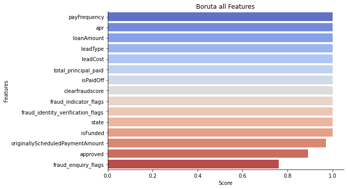

```python
sns_boruta_plot = sns.catplot(x="Score", y="Features", data = boruta_score[:], kind = "bar",
               height=5, aspect=1.9, palette='coolwarm')
plt.title("Boruta all Features")
```

```python
X_train, X_test, y_train, y_test = train_test_split(X, y_encoded, test_size=0.2, random_state=42)
```

```python
# Train the Random Forest model
rfc = RandomForestClassifier(n_estimators=100, random_state=42)
rfc.fit(X_train, y_train)

# Predict loan_risk for the test set
y_pred = rfc.predict(X_test)

# Evaluate the model
print(classification_report(y_test, y_pred))
```

```
              precision    recall  f1-score   support

           0       1.00      1.00      1.00      1891
           1       1.00      1.00      1.00      1487
           2       1.00      1.00      1.00      3842

    accuracy                           1.00      7220
   macro avg       1.00      1.00      1.00      7220
weighted avg       1.00      1.00      1.00      7220
```

```python
print("Accuracy on training set: {:.3f}".format(rfc.score(X_train, y_train)))
print("Accuracy on test set: {:.3f}".format(rfc.score(X_test, y_test)))
```

```
Accuracy on training set: 1.000
Accuracy on test set: 0.999
```

### ROC Curve

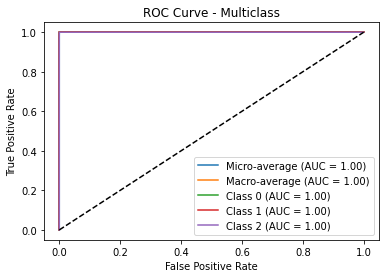

```python
from sklearn.metrics import roc_curve, auc
from sklearn.preprocessing import label_binarize
from sklearn.metrics import roc_auc_score

# Convert y_test and y_pred into one-hot encoded format
y_test_one_hot = label_binarize(y_test, classes=np.unique(y_test))
y_pred_one_hot = rfc.predict_proba(X_test)

# Compute ROC curve and AUC for each class
fpr = dict()
tpr = dict()
auc_scores = dict()
n_classes = y_test_one_hot.shape[1]

for i in range(n_classes):
    fpr[i], tpr[i], _ = roc_curve(y_test_one_hot[:, i], y_pred_one_hot[:, i])
    auc_scores[i] = auc(fpr[i], tpr[i])

# Compute micro-average ROC curve and AUC
fpr_micro, tpr_micro, _ = roc_curve(y_test_one_hot.ravel(), y_pred_one_hot.ravel())
auc_micro = auc(fpr_micro, tpr_micro)

# Compute macro-average ROC curve and AUC
all_fpr = np.unique(np.concatenate([fpr[i] for i in range(n_classes)]))
mean_tpr = np.zeros_like(all_fpr)
for i in range(n_classes):
    mean_tpr += np.interp(all_fpr, fpr[i], tpr[i])
mean_tpr /= n_classes
fpr_macro = all_fpr
tpr_macro = mean_tpr
auc_macro = auc(fpr_macro, tpr_macro)

# Plot ROC curves
plt.figure()
plt.plot(fpr_micro, tpr_micro, label=f"Micro-average (AUC = {auc_micro:.2f})")
plt.plot(fpr_macro, tpr_macro, label=f"Macro-average (AUC = {auc_macro:.2f})")

for i in range(n_classes):
    plt.plot(fpr[i], tpr[i], label=f"Class {i} (AUC = {auc_scores[i]:.2f})")

plt.plot([0, 1], [0, 1], 'k--')
plt.xlabel('False Positive Rate')
plt.ylabel('True Positive Rate')
plt.title('ROC Curve - Multiclass')
plt.legend(loc='lower right')
plt.show()
```

```python
mse = mean_squared_error(y_test,y_pred)
print ("Mean Squared Error: ", mse)

#r2
r2 = r2_score(y_test,y_pred)
print("R-squared: ", r2)

results_df = pd.DataFrame()
results_df["Actual"] = y_test
results_df["Predicted"] = y_pred
results_df
```

```
Mean Squared Error:  0.0023545706371191134
R-squared:  0.9967344101407926
```

|  | Actual | Predicted |
| --- | --- | --- |
| 0 | 1 | 1 |
| 1 | 2 | 2 |
| 2 | 1 | 1 |
| 3 | 2 | 2 |
| 4 | 0 | 0 |
| ... | ... | ... |
| 7215 | 2 | 2 |
| 7216 | 2 | 2 |
| 7217 | 2 | 2 |
| 7218 | 1 | 1 |
| 7219 | 1 | 1 |

7220 rows × 2 columns

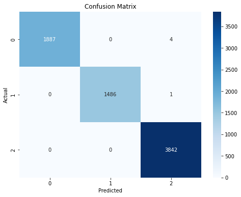

```python
# Print confusion matrix
cm = confusion_matrix(y_test, y_pred)
plt.figure(figsize=(8, 6))
sns.heatmap(cm, annot=True, cmap='Blues', fmt='d', xticklabels=rfc.classes_, yticklabels=rfc.classes_)
plt.xlabel('Predicted')
plt.ylabel('Actual')
plt.title('Confusion Matrix')
plt.show()
```

### Prediction of clearfraudscore

```python
from sklearn.ensemble import RandomForestRegressor

# Select the relevant columns for the analysis
selected_columns = ['payFrequency', 'apr', 'loanAmount', 'leadType', 'leadCost', 'total_principal_paid',
                    'isPaidOff', 'loan_risk', 'fraud_indicator_flags', 'fraud_enquiry_flags',
                    'fraud_identity_verification_flags', 'state', 'approved',
                    'isFunded', 'originallyScheduledPaymentAmount', 'clearfraudscore']
df = loan_clarity_df[selected_columns].copy()
```

```python
#one hot encoding
col_list = [col for col in df.columns.tolist() if
           df[col].dtype.name == "object"]
df_oh = df[col_list]
df = df.drop(col_list, 1)
df_oh = pd.get_dummies(df_oh)
df = pd.concat([df, df_oh], axis=1)
```

```python
df['loan_risk'] = label_encoder.fit_transform(loan_clarity_df['loan_risk'])
```

```python
y = df.clearfraudscore
X = df.drop("clearfraudscore", 1)
y = label_encoder.fit_transform(y)
colnames = X.columns
X['total_principal_paid'] = X['total_principal_paid'].fillna(0)
```

```python
rfc = RandomForestClassifier(n_jobs=1,class_weight="balanced_subsample",max_depth=5)
feat_selector2 = BorutaPy(rfc, n_estimators="auto",random_state=1)
```

```python
feat_selector2.fit(X.values,y.ravel())
```

```
BorutaPy(estimator=RandomForestClassifier(class_weight='balanced_subsample',
                                          max_depth=5, n_estimators=48,
                                          n_jobs=1,
                                          random_state=RandomState(MT19937) at 0x1C247C5CB40),
         n_estimators='auto',
         random_state=RandomState(MT19937) at 0x1C247C5CB40)
```

```python
feat_selector2.n_features_
```

```
2
```

```python
boruta_score2 = ranking(list(map(float, feat_selector2.ranking_)), selected_columns, order=-1)
boruta_score2 = pd.DataFrame(list(boruta_score2.items()), columns=['Features', 'Score'])
boruta_score2 = boruta_score2.sort_values("Score", ascending = False)

print('---------Features----------')
display(boruta_score2)
```

```
---------Features----------
```

|  | Features | Score |
| --- | --- | --- |
| 4 | leadCost | 1.00 |
| 6 | isPaidOff | 1.00 |
| 10 | fraud_identity_verification_flags | 0.98 |
| 1 | apr | 0.97 |
| 5 | total_principal_paid | 0.97 |
| 2 | loanAmount | 0.95 |
| 7 | loan_risk | 0.94 |
| 0 | payFrequency | 0.92 |
| 3 | leadType | 0.91 |
| 12 | approved | 0.83 |
| 11 | state | 0.73 |
| 9 | fraud_enquiry_flags | 0.62 |
| 13 | isFunded | 0.62 |
| 15 | clearfraudscore | 0.62 |
| 8 | fraud_indicator_flags | 0.59 |
| 14 | originallyScheduledPaymentAmount | 0.45 |

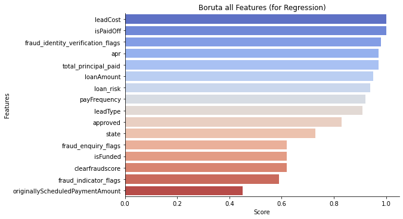

```python
sns_boruta_plot = sns.catplot(x="Score", y="Features", data = boruta_score2[:], kind = "bar",
               height=5, aspect=1.9, palette='coolwarm')
plt.title("Boruta all Features (for Regression)")
```

```python
# Split the data into training and testing sets
X_train, X_test, y_train, y_test = train_test_split(X, y, test_size=0.2, random_state=42)

# Train the Random Forest regressor model
rfr = RandomForestRegressor(n_estimators=100, random_state=42)
rfr.fit(X_train, y_train)

# Predict clearfraudscore for the test set
y_pred = rfr.predict(X_test)
```

```python
from sklearn.metrics import mean_squared_error, mean_absolute_error, r2_score, explained_variance_score


# Calculate performance metrics
mse = mean_squared_error(y_test, y_pred)
rmse = np.sqrt(mse)
mae = mean_absolute_error(y_test, y_pred)
r2 = r2_score(y_test, y_pred)
adjusted_r2 = 1 - (1-r2)*(len(y_test)-1)/(len(y_test)-X_test.shape[1]-1)
mpe = np.mean((y_test - y_pred) / y_test) * 100
mape = np.mean(np.abs((y_test - y_pred) / y_test)) * 100
explained_var = explained_variance_score(y_test, y_pred)

# Print performance metrics
print("Mean Squared Error (MSE):", mse)
print("Root Mean Squared Error (RMSE):", rmse)
print("Mean Absolute Error (MAE):", mae)
print("R-squared (R2):", r2)
print("Adjusted R-squared:", adjusted_r2)
print("Mean Percentage Error (MPE):", mpe)
print("Mean Absolute Percentage Error (MAPE):", mape)
print("Explained Variance Score:", explained_var)
```

```
Mean Squared Error (MSE): 2389.564146698384
Root Mean Squared Error (RMSE): 48.88316833735702
Mean Absolute Error (MAE): 38.827753324099724
R-squared (R2): 0.8516880150298096
Adjusted R-squared: 0.8502567525175099
Mean Percentage Error (MPE): -4.039228226161311
Mean Absolute Percentage Error (MAPE): 13.642781886661098
Explained Variance Score: 0.8516909400732121
```

```python
results_df = pd.DataFrame()
results_df["Actual"] = y_test
results_df["Predicted"] = y_pred
results_df
```

|  | Actual | Predicted |
| --- | --- | --- |
| 0 | 549 | 561.79 |
| 1 | 327 | 404.00 |
| 2 | 543 | 550.63 |
| 3 | 401 | 445.53 |
| 4 | 126 | 245.05 |
| ... | ... | ... |
| 7215 | 475 | 404.33 |
| 7216 | 367 | 412.89 |
| 7217 | 323 | 361.45 |
| 7218 | 654 | 595.48 |
| 7219 | 585 | 573.46 |

7220 rows × 2 columns

Hyper Parameter Tuning

```python
from sklearn.model_selection import train_test_split, GridSearchCV

param_grid = {'n_estimators': [50, 100, 150, 200], 'max_depth': [None, 5, 10, 15]}
grid_search = GridSearchCV(rfr, param_grid, cv=3)
grid_search.fit(X_train, y_train)
y_pred = grid_search.predict(X_test)

# Calculate performance metrics
mse = mean_squared_error(y_test, y_pred)
rmse = np.sqrt(mse)
mae = mean_absolute_error(y_test, y_pred)
r2 = r2_score(y_test, y_pred)
adjusted_r2 = 1 - (1-r2)*(len(y_test)-1)/(len(y_test)-X_test.shape[1]-1)
mpe = np.mean((y_test - y_pred) / y_test) * 100
mape = np.mean(np.abs((y_test - y_pred) / y_test)) * 100
explained_var = explained_variance_score(y_test, y_pred)

# Print performance metrics
print('Performance after Hyperparameter Tuning: \n')
print("Mean Squared Error (MSE):", mse)
print("Root Mean Squared Error (RMSE):", rmse)
print("Mean Absolute Error (MAE):", mae)
print("R-squared (R2):", r2)
print("Adjusted R-squared:", adjusted_r2)
print("Mean Percentage Error (MPE):", mpe)
print("Mean Absolute Percentage Error (MAPE):", mape)
print("Explained Variance Score:", explained_var)
```

```
Performance after Hyperparameter Tuning:

Mean Squared Error (MSE): 2360.8880271430658
Root Mean Squared Error (RMSE): 48.58897022106011
Mean Absolute Error (MAE): 38.918976475757034
R-squared (R2): 0.853467842626557
Adjusted R-squared: 0.8520537560728831
Mean Percentage Error (MPE): -4.204509551080908
Mean Absolute Percentage Error (MAPE): 13.730737455425738
Explained Variance Score: 0.8534679771254554
```

```python
best_params = grid_search.best_params_

# Display the best parameters
print("Best Parameters:")
for param, value in best_params.items():
    print(param + ": " + str(value))
```

```
Best Parameters:
max_depth: 15
n_estimators: 200
```

```python
results_df_GSCV = pd.DataFrame()
results_df_GSCV["Actual"] = y_test
results_df_GSCV["Predicted"] = y_pred
results_df_GSCV
```

|  | Actual | Predicted |
| --- | --- | --- |
| 0 | 549 | 562.364964 |
| 1 | 327 | 398.446513 |
| 2 | 543 | 547.617739 |
| 3 | 401 | 429.954973 |
| 4 | 126 | 240.258597 |
| ... | ... | ... |
| 7215 | 475 | 406.445005 |
| 7216 | 367 | 421.554555 |
| 7217 | 323 | 375.647013 |
| 7218 | 654 | 585.991816 |
| 7219 | 585 | 570.293501 |

7220 rows × 2 columns

In conclusion, this analysis provides insights into loan approval rates, loan risk distribution, and factors influencing loan risks.